# Cyclistic Case Study

Author

Dóra Szefcsik

# Background

## Industry

According to the [Meddin bike-sharing map](https://bikesharingworldmap.com/), bike-sharing systems are present in 1,590 cities, in 92 countries and on every continent (except Antarctica). In April 2023, the world had 1,914 systems in operation with a fleet of 8,980,314 bikes. For the latest industry trends, read [The Meddin Bike-sharing World Map Report](https://bikesharingworldmap.com/reports/bswm_mid2022report.pdf). The origins of bike-sharing can be traced back to grassroots efforts in the Netherlands in the mid-1960s. For more historical context, see [Bloomberg](https://www.bloomberg.com/news/features/2022-02-26/the-dutch-anarchists-who-launched-a-bikesharing-revolution).

## Company

Cyclistic is a (fictional) bike-share company launched in 2016. It operates a fleet of **5,824 bikes** that are geotracked and locked into a network of **1419 stations** across Chicago. The bikes can be unlocked from one station and returned to any other station in the system at any time.

# Business Task

Until now, Cyclistic’s marketing strategy relied on building general awareness and appealing to broad consumer segments. One approach that helped achieve this was the flexibility of its pricing plans: single-ride passes, full-day passes, and annual memberships.

Customers who purchase single-ride or full-day passes are referred to as **casual riders** and customers who buy annual memberships are called **Cyclistic members**. In order to maximize revenue for the bike-sharing company, management set a clear objective to develop marketing strategies aimed at converting casual riders into annual members.

## The focus of the analysis

Analysing historical bike trip data to identify trends that can guide Cyclistic’s future marketing program.

## Business Questions

**In what ways do annual members and casual riders use Cyclistic bikes differently?**

- What **time** of the day/week/month/year do members and casual riders use the service?
- Do members and casual users differ in **the time they spend cycling**?
- What **types of bikes** do members and casual users prefer?
- Are there any other differences that can help us **better understand the needs** of occasional and year-round users?

# Preparing the data

## Data Sources

The dataset is acquired from [Divvy’s public data](https://divvy-tripdata.s3.amazonaws.com/index.html) and made available by Motivate International Inc. under this [license](https://ride.divvybikes.com/data-license-agreement). It includes bike rides between **1 April 2022** and **31 March 2023**.

## Data Credibility

- **Reliable:** Lyft Bikes and Scooters, LLC (Bikeshare) operates the City of Chicago’s Divvy bicycle sharing service. Bikeshare makes certain Divvy system data owned by the City available to the public. The City of Chicago owns all right, title, and interest in the Data.
- **Original:** the data is collected by the Divvy systems
- **Comprehensive:** the data contains all critical information needed to answer the business question
- **Current:** the data covers the last 12 month
- **Cited:** the data is collected and maintained by a credible organization
- **Complies with Data Privacy:** the data is anonymised and does not contain any personally identifiable information
- **Unbiased:** contains data that is representative of all users of the bike share service

## Downloading and storing the data

1. Downloaded the data that covers the last 12 month from: [Divvy’s public historical trip data](https://divvy-tripdata.s3.amazonaws.com/index.html)
2. Unzipped the files
3. Opened the csv files one-by-one in Excel for exploration
4. Assessed the number of variables and the length of the data and decided to continue the data processing in RStudio

# Exploring the data

## Library and Setup

```r
Sys.setlocale("LC_ALL","English")
```

```
[1] "LC_COLLATE=English_United States.1252;LC_CTYPE=English_United States.1252;LC_MONETARY=English_United States.1252;LC_NUMERIC=C;LC_TIME=English_United States.1252"
```

Required packages:

```r
pacman::p_load(
  data.table,   ## fread function
  skimr,        ## summary statistics
  writexl,      ## xlsx exporter
  tidyverse,    ## data cleaning and manipulation
  janitor,      ## data cleaning
  naniar,       ## exploring missing data
  visdat,       ## visualization of missing data
  ggplot2,      ## visualization
  paletteer,    ## color palettes
  scales,       ## scaling
  ggthemes,     ## extra themes for plotting
  gt,           ## making tables
  knitr,        ## report generation
  leaflet,      ## interactive maps
  widgetframe   ## responsive iFrame
)
```

## Loading the data

Reading data from multiple files:

```r
bike_rides_raw <-
  list.files(path = "~/R/website/projects/cyclistic", pattern = "*.csv") |>
  map(~ fread(., data.table = TRUE, header = TRUE, fill = FALSE,
              showProgress = TRUE, na.strings = c("",NA))
      ) |>
  bind_rows()
```

## Exploration

```r
class(bike_rides_raw)
```

```
[1] "data.table" "data.frame"
```

```r
setkey(bike_rides_raw, ride_id)
```

Having a glimpse at the data:

```r
glimpse(bike_rides_raw)
```

```
Rows: 5,803,720
Columns: 13
$ ride_id            <chr> "00000179CF2C4FB5", "0000038F578A7278", "0000047373~
$ rideable_type      <chr> "electric_bike", "electric_bike", "electric_bike", ~
$ started_at         <dttm> 2022-07-28 09:02:27, 2022-12-15 15:36:06, 2022-07-~
$ ended_at           <dttm> 2022-07-28 09:13:51, 2022-12-15 15:44:35, 2022-07-~
$ start_station_name <chr> "Ellis Ave & 55th St", "Lakeview Ave & Fullerton Pk~
$ start_station_id   <chr> "KA1504000076", "TA1309000019", "13022", "13193", N~
$ end_station_name   <chr> "Ellis Ave & 55th St", "Clark St & Elm St", "Calume~
$ end_station_id     <chr> "KA1504000076", "TA1307000039", "13102", "TA1305000~
$ start_lat          <dbl> 41.79424, 41.92583, 41.89221, 41.92185, 41.90000, 4~
$ start_lng          <dbl> -87.60134, -87.63882, -87.61183, -87.64402, -87.690~
$ end_lat            <dbl> 41.79430, 41.90297, 41.85761, 41.90312, 41.91000, 4~
$ end_lng            <dbl> -87.60145, -87.63128, -87.61941, -87.67394, -87.690~
$ member_casual      <chr> "casual", "casual", "casual", "casual", "member", "~
```

Checking the summary statistics:

```r
summary(bike_rides_raw)
```

```
   ride_id          rideable_type        started_at
 Length:5803720     Length:5803720     Min.   :2022-04-01 00:01:48.00
 Class :character   Class :character   1st Qu.:2022-06-18 23:27:00.25
 Mode  :character   Mode  :character   Median :2022-08-13 11:37:32.00
                                       Mean   :2022-08-25 07:04:55.95
                                       3rd Qu.:2022-10-14 18:04:21.00
                                       Max.   :2023-03-31 23:59:28.00

    ended_at                      start_station_name start_station_id
 Min.   :2022-04-01 00:02:15.00   Length:5803720     Length:5803720
 1st Qu.:2022-06-18 23:51:55.75   Class :character   Class :character
 Median :2022-08-13 12:00:07.50   Mode  :character   Mode  :character
 Mean   :2022-08-25 07:23:54.70
 3rd Qu.:2022-10-14 18:19:10.25
 Max.   :2023-04-03 11:41:11.00

 end_station_name   end_station_id       start_lat       start_lng
 Length:5803720     Length:5803720     Min.   :41.64   Min.   :-87.84
 Class :character   Class :character   1st Qu.:41.88   1st Qu.:-87.66
 Mode  :character   Mode  :character   Median :41.90   Median :-87.64
                                       Mean   :41.90   Mean   :-87.65
                                       3rd Qu.:41.93   3rd Qu.:-87.63
                                       Max.   :42.07   Max.   :-87.52

    end_lat         end_lng       member_casual
 Min.   : 0.00   Min.   :-88.14   Length:5803720
 1st Qu.:41.88   1st Qu.:-87.66   Class :character
 Median :41.90   Median :-87.64   Mode  :character
 Mean   :41.90   Mean   :-87.65
 3rd Qu.:41.93   3rd Qu.:-87.63
 Max.   :42.37   Max.   :  0.00
 NA's   :5855    NA's   :5855
```

Looking for duplicates:

```r
sum(duplicated(bike_rides_raw))
```

```
[1] 0
```

Skimming the data table:

```r
skim_without_charts(bike_rides_raw)
```

Data summary

| Name | bike_rides_raw |
| --- | --- |
| Number of rows | 5803720 |
| Number of columns | 13 |
| Key | ride_id |
| _______________________ |  |
| Column type frequency: |  |
| character | 7 |
| numeric | 4 |
| POSIXct | 2 |
| ________________________ |  |
| Group variables | None |

**Variable type: character**

| skim_variable | n_missing | complete_rate | min | max | empty | n_unique | whitespace |
| --- | --- | --- | --- | --- | --- | --- | --- |
| ride_id | 0 | 1.00 | 16 | 16 | 0 | 5803720 | 0 |
| rideable_type | 0 | 1.00 | 11 | 13 | 0 | 3 | 0 |
| start_station_name | 839082 | 0.86 | 7 | 64 | 0 | 1699 | 0 |
| start_station_id | 839214 | 0.86 | 3 | 36 | 0 | 1315 | 0 |
| end_station_name | 896319 | 0.85 | 9 | 64 | 0 | 1723 | 0 |
| end_station_id | 896460 | 0.85 | 3 | 36 | 0 | 1320 | 0 |
| member_casual | 0 | 1.00 | 6 | 6 | 0 | 2 | 0 |

**Variable type: numeric**

| skim_variable | n_missing | complete_rate | mean | sd | p0 | p25 | p50 | p75 | p100 |
| --- | --- | --- | --- | --- | --- | --- | --- | --- | --- |
| start_lat | 0 | 1 | 41.90 | 0.05 | 41.64 | 41.88 | 41.90 | 41.93 | 42.07 |
| start_lng | 0 | 1 | -87.65 | 0.03 | -87.84 | -87.66 | -87.64 | -87.63 | -87.52 |
| end_lat | 5855 | 1 | 41.90 | 0.07 | 0.00 | 41.88 | 41.90 | 41.93 | 42.37 |
| end_lng | 5855 | 1 | -87.65 | 0.11 | -88.14 | -87.66 | -87.64 | -87.63 | 0.00 |

**Variable type: POSIXct**

| skim_variable | n_missing | complete_rate | min | max | median | n_unique |
| --- | --- | --- | --- | --- | --- | --- |
| started_at | 0 | 1 | 2022-04-01 00:01:48 | 2023-03-31 23:59:28 | 2022-08-13 11:37:32 | 4874281 |
| ended_at | 0 | 1 | 2022-04-01 00:02:15 | 2023-04-03 11:41:11 | 2022-08-13 12:00:07 | 4887969 |

## Data Description

The raw data set contains data on **5,803,720 bike rides** along **13 variables**:

- `ride_id` *<chr>* : a 16-digit unique trip identifier, consisting of letters and numbers
- `rideable_type` *<chr>* : type of bike, assuming one of three categories:
  - classic_bike
  - docked_bike
  - electric_bike
- `started_at` *<dttm>* : the start date and time of the trip
- `ended_at` *<dttm>* : the end date and time of the trip
- `start_station_name` *<chr>* : the name of the station from which the bike trip started
- `start_station_id` *<chr>* : the ID of the station from which the bike trip started
- `end_station_name` *<chr>* : the name of the station where the bike trip ended
- `end_station_id` *<chr>* : the ID of the station where the bike trip ended
- `start_lat` *<dbl>* : start latitude, ranges between 41.64 and 42.07 degrees
- `start_lng` *<dbl>* : start longitude, ranges between -87.84 and -87.52 degrees
- `end_lat` *<dbl>* : end latitude, ranges between **0.00** and 42.37 degrees
- `end_lng` *<dbl>* : end longitude, ranges between -88.14 and **0.00** degrees
- `member_casual` **<chr>** : type of user, assuming one of two categories:
  - member
  - casual

## Observations

- Blank cells and missing data to check:
  - start_station_name (n_empty=839082)
  - start_station_id (n_empty=839214)
  - end_station_name (n_empty=896319)
  - end_station_id (n_empty=896460)
  - end_lat (n_missing=5855)
  - end_lng (n_missing=5855)
- Inconsistent number of decimals to check:
  - start_lat
  - start_lng
  - end_lat
  - eng_lng
- Outlying data to check: end_lat=0.00, end_lng=0.00
- Data type - string to factor:
  - rideable_type
  - member_casual
  - start_station_name
  - end_station_name

Exporting a backup file before going on with data cleaning:

```r
fwrite(bike_rides_raw, "~/R/backup/cyclistic/bike_rides_raw_01.csv")
```

# Data cleaning

Transforming raw data into tidy data that is suitable for analysis.

## Variable names

Column names:

```r
colnames(bike_rides_raw)
```

```
 [1] "ride_id"            "rideable_type"      "started_at"
 [4] "ended_at"           "start_station_name" "start_station_id"
 [7] "end_station_name"   "end_station_id"     "start_lat"
[10] "start_lng"          "end_lat"            "end_lng"
[13] "member_casual"
```

Renaming variables:

```r
bike_rides_raw <- bike_rides_raw |>
  rename(
    bike_type = rideable_type,
    start_time = started_at,
    end_time = ended_at,
    user_type = member_casual
  )

colnames(bike_rides_raw)
```

```
 [1] "ride_id"            "bike_type"          "start_time"
 [4] "end_time"           "start_station_name" "start_station_id"
 [7] "end_station_name"   "end_station_id"     "start_lat"
[10] "start_lng"          "end_lat"            "end_lng"
[13] "user_type"
```

## Data types

Ensuring that each column has the correct data type:

```r
str(bike_rides_raw)
```

```
Classes 'data.table' and 'data.frame':  5803720 obs. of  13 variables:
 $ ride_id           : chr  "00000179CF2C4FB5" "0000038F578A7278" "0000047373295F85" "000004C3185FDDE9" ...
 $ bike_type         : chr  "electric_bike" "electric_bike" "electric_bike" "electric_bike" ...
 $ start_time        : POSIXct, format: "2022-07-28 09:02:27" "2022-12-15 15:36:06" ...
 $ end_time          : POSIXct, format: "2022-07-28 09:13:51" "2022-12-15 15:44:35" ...
 $ start_station_name: chr  "Ellis Ave & 55th St" "Lakeview Ave & Fullerton Pkwy" "Streeter Dr & Grand Ave" "Larrabee St & Webster Ave" ...
 $ start_station_id  : chr  "KA1504000076" "TA1309000019" "13022" "13193" ...
 $ end_station_name  : chr  "Ellis Ave & 55th St" "Clark St & Elm St" "Calumet Ave & 18th St" "Honore St & Division St" ...
 $ end_station_id    : chr  "KA1504000076" "TA1307000039" "13102" "TA1305000034" ...
 $ start_lat         : num  41.8 41.9 41.9 41.9 41.9 ...
 $ start_lng         : num  -87.6 -87.6 -87.6 -87.6 -87.7 ...
 $ end_lat           : num  41.8 41.9 41.9 41.9 41.9 ...
 $ end_lng           : num  -87.6 -87.6 -87.6 -87.7 -87.7 ...
 $ user_type         : chr  "casual" "casual" "casual" "casual" ...
 - attr(*, ".internal.selfref")=<externalptr>
 - attr(*, "sorted")= chr "ride_id"
```

Changing data types from string to factor where variables represent categorical data:

```r
bike_rides_raw$bike_type <- as.factor(bike_rides_raw$bike_type)
bike_rides_raw$user_type <- as.factor(bike_rides_raw$user_type)
```

## Incorrect data

Let’s find out if there are any misspellings, incorrect naming or other types of errors in our data.

### Divvy Bicycle Stations

Official Divvy stations data is available at [this link](https://data.cityofchicago.org/Transportation/Divvy-Bicycle-Stations/bbyy-e7gq/data).

```r
divvy_stations <- read_csv("~/R/divvy/Divvy_Bicycle_Stations.csv")
```

Selecting variables for comparison:

```r
divvy_stations <- divvy_stations |>
  select(ID, station_name = "Station Name", Latitude, Longitude) |>
  unite(
    col = Location,
    Latitude, Longitude,
    sep = ", "
  )
```

According to Divvy, their system has **1419** unique stations.

Filtering all unique start station names and IDs in our data table:

```r
start_stations <- bike_rides_raw |>
  mutate(across(c(start_lat, start_lng), ~ round(., 5))) |>
  distinct(start_station_name, start_station_id, start_lat, start_lng) |>
  filter(!is.na(start_station_name) | !is.na(start_station_id)) |>
  select(station_name = start_station_name, station_id = start_station_id, lat = start_lat, lng = start_lng)

head(start_stations)
```

| station_name | station_id | lat | lng |
| --- | --- | --- | --- |
| Ellis Ave & 55th St | KA1504000076 | 41.79424 | -87.60134 |
| Lakeview Ave & Fullerton Pkwy | TA1309000019 | 41.92583 | -87.63882 |
| Streeter Dr & Grand Ave | 13022 | 41.89221 | -87.61183 |
| Larrabee St & Webster Ave | 13193 | 41.92185 | -87.64402 |
| Racine Ave & Belmont Ave | TA1308000019 | 41.93965 | -87.65887 |
| Wells St & Elm St | KA1504000135 | 41.90316 | -87.63478 |

Filtering all unique end station names and IDs in our data table:

```r
end_stations <- bike_rides_raw |>
  mutate(across(c(end_lat, end_lng), ~ round(., 5))) |>
  distinct(end_station_name, end_station_id, end_lat, end_lng) |>
  filter(!is.na(end_station_name) | !is.na(end_station_id)) |>
  select(station_name = end_station_name, station_id = end_station_id, lat = end_lat, lng = end_lng)

head(end_stations)
```

| station_name | station_id | lat | lng |
| --- | --- | --- | --- |
| Ellis Ave & 55th St | KA1504000076 | 41.79430 | -87.60145 |
| Clark St & Elm St | TA1307000039 | 41.90297 | -87.63128 |
| Calumet Ave & 18th St | 13102 | 41.85761 | -87.61941 |
| Honore St & Division St | TA1305000034 | 41.90312 | -87.67394 |
| Sheffield Ave & Wrightwood Ave | TA1309000023 | 41.92871 | -87.65383 |
| Clark St & Armitage Ave | 13146 | 41.91831 | -87.63628 |

Joining together the two data tables:

```r
stations <- rbind(start_stations,end_stations)

stations <- unique(stations)

stations <- stations |> arrange(stations$station_id)

head(stations)
```

| station_name | station_id | lat | lng |
| --- | --- | --- | --- |
| MTV Hubbard St | 021320 | 41.89 | -87.68 |
| Public Rack - Fullerton Ave & Narragansett Ave | 1011 | 41.92 | -87.79 |
| Public Rack - Langley Ave & 49th St | 1012 | 41.81 | -87.61 |
| Public Rack - Langley Ave & 49th St | 1012 | 41.80 | -87.61 |
| Public Rack - Pulaski Rd & Lake St | 1013 | 41.89 | -87.73 |
| Public Rack - Richmond St & Thorndale Ave | 1014 | 41.99 | -87.70 |

Exporting data for further exploration in Excel:

```r
write_xlsx(divvy_stations, "~/R/backup/cyclistic/divvy_stations.xlsx")

write_xlsx(stations, "~/R/backup/cyclistic/stations.xlsx")
```

### Comparing station names and IDs with Divvy station data:

Observations:

- **One station ID** is associated with several **different coordinates**.
- Some station names and identifiers refer to a company **warehouse** or **repair station**:
  - *“WEST CHI-WATSON - DIVVY 001 Warehouse test station”*
  - *“WestChi - DIVVY 001 Warehouse test station”*
  - *“WEST CHI-WATSON - DIVVY 001”*
  - *“Base - 2132 W Hubbard - Hubbard Bike-checking (LBS-WH-TEST)”*
  - *“Base - 2132 W Hubbard Warehouse - Hubbard Bike-checking (LBS-WH-TEST)”*
  - *“DIVVY CASSETTE REPAIR MOBILE STATION - DIVVY CASSETTE REPAIR MOBILE STATION”*
  - *“NewHastings - 2059 Hastings Warehouse Station”*
- We can spot a few **typos**:
  - *Public Rack - Pulaski Rd &**amp;** 65th St–> Public Rack - Pulaski Rd & 65th St*
  - *Public Rack - Kedzie Ave &**amp;** 62nd Pl –> Public Rack - Kedzie Ave & 62nd Pl*
- We can also find **inconsistent naming**:
  - *“Bissell St & Armitage Ave - Charging”* or *“Bissell St & Armitage Ave*”*
  - *“Base - 2132 W Hubbard”* or *“Base - 2132 W Hubbard Warehouse”*
  - *“WestChi”* or *“WEST CHI-WATSON”*
- and station names that don’t exist in the Divvy database:
  - *“Elizabeth St & Randolph St”*
  - *“Stony Island Ave & 63rd St”*

Saving a backup file:

```r
fwrite(bike_rides_raw, "~/R/backup/cyclistic/bike_rides_raw_02.csv")
```

### Correcting misspellings

Listing the spelling errors:

```r
bike_rides_raw |>
  filter(start_station_name == "Public Rack - Pulaski Rd &amp; 65th St" |
           start_station_name == "Public Rack - Kedzie Ave &amp; 62nd Pl") |>
  count(start_station_id, start_station_name, sort = T)
```

| start_station_id | start_station_name | n |
| --- | --- | --- |
| 1038 | Public Rack - Kedzie Ave & 62nd Pl | 2 |
| 1033 | Public Rack - Pulaski Rd & 65th St | 1 |

```r
bike_rides_raw |>
  filter(end_station_name == "Public Rack - Pulaski Rd &amp; 65th St" |
           end_station_name == "Public Rack - Kedzie Ave &amp; 62nd Pl") |>
  count(end_station_id, end_station_name, sort = T)
```

| end_station_id | end_station_name | n |
| --- | --- | --- |

Replacing incorrect start station names with the correct names:

```r
bike_rides_raw$start_station_name[bike_rides_raw$start_station_name == "Public Rack - Pulaski Rd &amp; 65th St"] <- "Public Rack - Pulaski Rd & 65th St"

bike_rides_raw$start_station_name[bike_rides_raw$start_station_name ==  "Public Rack - Kedzie Ave &amp; 62nd Pl"] <- "Public Rack - Kedzie Ave & 62nd Pl"
```

Checking the results:

```r
bike_rides_raw |>
  filter(start_station_id == 1038 |
         start_station_id == 1033 |
         start_station_name == "Public Rack - Pulaski Rd & 65th St" |
         start_station_name == "Public Rack - Kedzie Ave & 62nd Pl") |>
  count(start_station_id, start_station_name, sort = T)
```

| start_station_id | start_station_name | n |
| --- | --- | --- |
| 1038 | Public Rack - Kedzie Ave & 62nd Pl | 25 |
| 1033 | Public Rack - Pulaski Rd & 65th St | 15 |

### Dealing with inconsistent naming

- *“Bissell St & Armitage Ave - Charging”* –> “*Bissell St & Armitage Ave*“*
- *“Base - 2132 W Hubbard”* –> “*Base - 2132 W Hubbard Warehouse”*
- *“WestChi”* –> “*WEST CHI-WATSON”*

```r
bike_rides_raw |>
  filter(start_station_name == "Bissell St & Armitage Ave - Charging" |
           start_station_name == "Base - 2132 W Hubbard" |
           start_station_name == "Base - 2132 W Hubbard Warehouse" |
           start_station_name == "WestChi" |
           start_station_name == "WEST CHI-WATSON") |>
  count(start_station_id, start_station_name, sort = T)
```

| start_station_id | start_station_name | n |
| --- | --- | --- |
| Hubbard Bike-checking (LBS-WH-TEST) | Base - 2132 W Hubbard | 1365 |
| Hubbard Bike-checking (LBS-WH-TEST) | Base - 2132 W Hubbard Warehouse | 461 |
| DIVVY 001 - Warehouse test station | WestChi | 6 |
| DIVVY 001 - Warehouse test station | WEST CHI-WATSON | 4 |
| DIVVY 001 | WEST CHI-WATSON | 3 |

```r
bike_rides_raw |>
  filter(end_station_name == "Bissell St & Armitage Ave - Charging" |
           end_station_name == "Base - 2132 W Hubbard" |
           end_station_name == "Base - 2132 W Hubbard Warehouse" |
           end_station_name == "WestChi" |
           end_station_name == "WEST CHI-WATSON") |>
  count(end_station_id, end_station_name, sort = T)
```

| end_station_id | end_station_name | n |
| --- | --- | --- |
| Hubbard Bike-checking (LBS-WH-TEST) | Base - 2132 W Hubbard | 183 |
| Hubbard Bike-checking (LBS-WH-TEST) | Base - 2132 W Hubbard Warehouse | 31 |
| chargingstx1 | Bissell St & Armitage Ave - Charging | 2 |

Correcting station names:

```r
## start station names

bike_rides_raw$start_station_name[bike_rides_raw$start_station_name == "Base - 2132 W Hubbard"] <- "Base - 2132 W Hubbard Warehouse"

bike_rides_raw$start_station_name[bike_rides_raw$start_station_name == "WestChi"] <- "WEST CHI-WATSON"

## end station names

bike_rides_raw$end_station_name[bike_rides_raw$end_station_name == "Base - 2132 W Hubbard"] <- "Base - 2132 W Hubbard Warehouse"

bike_rides_raw$end_station_name[bike_rides_raw$end_station_name == "Bissell St & Armitage Ave - Charging"] <- "Bissell St & Armitage Ave*"
```

Unifying the Divvy Warehouse ID:

```r
bike_rides_raw$start_station_id[bike_rides_raw$start_station_id == "DIVVY 001 - Warehouse test station"] <- "DIVVY 001"
```

Filtering for *“Elizabeth St & Randolph St.”* and *“Stony Island Ave & 63rd St”*

```r
bike_rides_raw |>
  filter(start_station_name == "Elizabeth St & Randolph St" |
    start_station_name == "Stony Island Ave & 63rd St" |
    start_station_id == "23001" |
    start_station_id == "653B") |>
  count(start_station_id, start_station_name, sort = T)
```

| start_station_id | start_station_name | n |
| --- | --- | --- |
| 23001 | Elizabeth St & Randolph St | 274 |
| NA | Elizabeth St & Randolph St | 124 |
| 653B | Stony Island Ave & 63rd St | 15 |
| NA | Stony Island Ave & 63rd St | 8 |

```r
bike_rides_raw |>
  filter(end_station_name == "Elizabeth St & Randolph St" |
    end_station_name == "Stony Island Ave & 63rd St" |
    end_station_id == "23001" |
    end_station_id == "653B") |>
  count(end_station_id, end_station_name, sort = T)
```

| end_station_id | end_station_name | n |
| --- | --- | --- |
| 23001 | Elizabeth St & Randolph St | 295 |
| NA | Elizabeth St & Randolph St | 133 |
| 653B | Stony Island Ave & 63rd St | 12 |
| NA | Stony Island Ave & 63rd St | 8 |

Replacing missing IDs:

```r
bike_rides_raw <- bike_rides_raw |>
  mutate(
    start_station_id = ifelse(start_station_name == "Elizabeth St & Randolph St" & is.na(start_station_id),
      "23001", start_station_id
    ),
    start_station_id = ifelse(start_station_name == "Stony Island Ave & 63rd St" & is.na(start_station_id),
      "653B", start_station_id
    )
  )

bike_rides_raw <- bike_rides_raw |>
  mutate(
    end_station_id = ifelse(end_station_name == "Elizabeth St & Randolph St" & is.na(end_station_id),
      "23001", end_station_id
    ),
    end_station_id = ifelse(end_station_name == "Stony Island Ave & 63rd St" & is.na(end_station_id),
      "653B", end_station_id
    )
  )
```

Filtering for cases where station names are missing but IDs are present:

```r
bike_rides_raw |>
  filter(is.na(start_station_name) & !is.na(start_station_id)) |>
  count(start_station_name, sort = T)
```

| start_station_name | n |
| --- | --- |

```r
bike_rides_raw |>
  filter(is.na(end_station_name) & !is.na(end_station_id)) |>
  count(end_station_name, sort = T)
```

| end_station_name | n |
| --- | --- |

No other cases are found where the station ID is present.

Filtering for cases where station IDs are missing but names are present:

```r
bike_rides_raw |>
  filter(is.na(start_station_id) & !is.na(start_station_name)) |>
  count(start_station_id, sort = T)
```

| start_station_id | n |
| --- | --- |

```r
bike_rides_raw |>
  filter(is.na(end_station_id) & !is.na(end_station_name)) |>
  count(end_station_id, sort = T)
```

| end_station_id | n |
| --- | --- |

No other cases are found where the station name is present.

### Null end coordinates

```r
bike_rides_raw |>
  subset(end_lat == 0 | end_lng == 0)
```

| ride_id | bike_type | start_time | end_time | start_station_name | start_station_id | end_station_name | end_station_id | start_lat | start_lng | end_lat | end_lng | user_type |
| --- | --- | --- | --- | --- | --- | --- | --- | --- | --- | --- | --- | --- |
| 0A6988FE859F4D54 | classic_bike | 2022-11-09 10:58:37 | 2022-11-09 11:06:21 | LaSalle St & Jackson Blvd | TA1309000004 | Green St & Madison Ave* | chargingstx07 | 41.87817 | -87.63193 | 0 | 0 | member |
| 3B47B333C0D186F0 | classic_bike | 2022-11-09 13:39:03 | 2022-11-09 13:44:38 | Franklin St & Adams St (Temp) | TA1309000008 | Green St & Madison Ave* | chargingstx07 | 41.87943 | -87.63550 | 0 | 0 | member |
| 42AF82C53D831251 | electric_bike | 2022-11-09 16:17:40 | 2022-11-09 16:38:06 | Laflin St & Cullerton St | 13307 | Green St & Madison Ave* | chargingstx07 | 41.85492 | -87.66369 | 0 | 0 | casual |
| 6AFE1471227BD76F | classic_bike | 2022-11-09 16:17:16 | 2022-11-09 16:26:17 | Morgan St & Polk St | TA1307000130 | Green St & Madison Ave* | chargingstx07 | 41.87174 | -87.65103 | 0 | 0 | casual |
| 75DE33501313D0CE | classic_bike | 2022-11-09 15:52:08 | 2022-11-09 15:52:23 | Green St & Madison St | TA1307000120 | Green St & Madison Ave* | chargingstx07 | 41.88189 | -87.64879 | 0 | 0 | member |
| 7F49424E860E7094 | classic_bike | 2022-11-09 13:27:04 | 2022-11-09 13:28:28 | Green St & Washington Blvd | 13053 | Green St & Madison Ave* | chargingstx07 | 41.88318 | -87.64872 | 0 | 0 | member |
| BB8AA29838266294 | classic_bike | 2022-11-09 11:32:53 | 2022-11-09 11:37:30 | Canal St & Adams St | 13011 | Green St & Madison Ave* | chargingstx07 | 41.87926 | -87.63990 | 0 | 0 | member |
| E9495F1DC3475D41 | classic_bike | 2022-11-09 12:21:55 | 2022-11-09 12:26:18 | Aberdeen St & Randolph St | 18062 | Green St & Madison Ave* | chargingstx07 | 41.88411 | -87.65426 | 0 | 0 | member |

We can find 8 rides where the end station is *Green St & Madison Ave** but the coordinates are missing.

Searching for *Green St & Madison Ave** station coordinates:

```r
bike_rides_raw |>
  filter(start_station_name == "Green St & Madison Ave*") |>
  count(start_station_name, start_station_id, start_lat, start_lng, sort = T) |>
  head(10)
```

| start_station_name | start_station_id | start_lat | start_lng | n |
| --- | --- | --- | --- | --- |
| Green St & Madison Ave* | chargingstx07 | 41.88183 | -87.64883 | 320 |
| Green St & Madison Ave* | chargingstx07 | 41.88162 | -87.64887 | 1 |
| Green St & Madison Ave* | chargingstx07 | 41.88164 | -87.64889 | 1 |
| Green St & Madison Ave* | chargingstx07 | 41.88164 | -87.64895 | 1 |
| Green St & Madison Ave* | chargingstx07 | 41.88167 | -87.64880 | 1 |
| Green St & Madison Ave* | chargingstx07 | 41.88167 | -87.64891 | 1 |
| Green St & Madison Ave* | chargingstx07 | 41.88168 | -87.64881 | 1 |
| Green St & Madison Ave* | chargingstx07 | 41.88168 | -87.64889 | 1 |
| Green St & Madison Ave* | chargingstx07 | 41.88169 | -87.64902 | 1 |
| Green St & Madison Ave* | chargingstx07 | 41.88170 | -87.64840 | 1 |

```r
bike_rides_raw |>
  filter(end_station_name == "Green St & Madison Ave*") |>
  count(end_station_name, end_station_id, end_lat, end_lng, sort = T) |>
  head(10)
```

| end_station_name | end_station_id | end_lat | end_lng | n |
| --- | --- | --- | --- | --- |
| Green St & Madison Ave* | chargingstx07 | 41.88183 | -87.64883 | 495 |
| Green St & Madison Ave* | chargingstx07 | 0.00000 | 0.00000 | 8 |
| Green St & Madison Ave* | chargingstx07 | 41.88188 | -87.64895 | 2 |
| Green St & Madison Ave* | chargingstx07 | 41.88183 | -87.64883 | 1 |

Replacing zero coordinates with the correct values:

```r
bike_rides_raw$end_lat[bike_rides_raw$end_lat == 0] <- 41.88183
bike_rides_raw$end_lng[bike_rides_raw$end_lng == 0] <- -87.64883
```

Saving a backup file:

```r
fwrite(bike_rides_raw, "~/R/backup/cyclistic/bike_rides_raw_03.csv")
```

## Data Manipulation

### New variable: `travel_time`

Calculating the duration of each bike ride in minutes:

```r
bike_rides_raw <- bike_rides_raw |>
  mutate(
    travel_time = round(
      difftime(
        end_time, start_time,
        units = "mins"
      ),
      digits = 2
    ), .after = end_time
  )

bike_rides_raw$travel_time <- as.numeric(bike_rides_raw$travel_time)
```

### New time units

We are adding new columns that list the date, year, month, day and hour of each trip. This will allow us to aggregate data for different time units.

`date`

```r
bike_rides_raw$date <- as.Date(bike_rides_raw$start_time)
```

`month`

```r
bike_rides_raw$month <- format(as.Date(bike_rides_raw$date), "%B")

bike_rides_raw$month <- ordered(bike_rides_raw$month,
  levels = c(
    "January", "February", "March",
    "April", "May", "June", "July",
    "August", "September", "October",
    "November", "December"
  )
)
```

`day`

```r
bike_rides_raw$day <- as.integer(format(as.Date(bike_rides_raw$date), "%d"))
```

`weekday`

```r
bike_rides_raw$weekday <- format(as.Date(bike_rides_raw$date), "%A")

bike_rides_raw$weekday <- ordered(bike_rides_raw$weekday,
  levels = c(
    "Monday", "Tuesday", "Wednesday",
    "Thursday", "Friday", "Saturday",
    "Sunday"
  )
)
```

`hour`

```r
bike_rides_raw$hour <- as.integer(format(bike_rides_raw$start_time, "%H"))
```

A glimpse at the new time units:

```r
bike_rides_raw |>
  select(start_time, date, month, day, weekday, hour) |>
  head()
```

| start_time | date | month | day | weekday | hour |
| --- | --- | --- | --- | --- | --- |
| 2022-07-28 09:02:27 | 2022-07-28 | July | 28 | Thursday | 9 |
| 2022-12-15 15:36:06 | 2022-12-15 | December | 15 | Thursday | 15 |
| 2022-07-22 16:56:46 | 2022-07-22 | July | 22 | Friday | 16 |
| 2022-07-17 13:01:54 | 2022-07-17 | July | 17 | Sunday | 13 |
| 2022-07-02 20:02:36 | 2022-07-02 | July | 2 | Saturday | 20 |
| 2022-06-12 05:12:17 | 2022-06-12 | June | 12 | Sunday | 5 |

### New variable: `time_of_day`

Classifying the extracted time by time of the day:

```r
## a column time_of_day is created using logic with case_when()
## to classify rows into
## morning rush/morning/lunchtime/afternoon/afternoon rush/evening/night
## based on their hour of departure

bike_rides_raw <- bike_rides_raw |>
  mutate(
    time_of_day = case_when(
      hour >= 3 & hour < 6 ~ "Dawn",
      hour >= 6 & hour < 9 ~ "Early morning",
      hour >= 9 & hour < 12 ~ "Late morning",
      hour >= 12 & hour < 15 ~ "Early afternoon",
      hour >= 15 & hour < 18 ~ "Late afternoon",
      hour >= 18 & hour < 21 ~ "Early evening",
      hour >= 21 & hour < 24 ~ "Late evening",
      hour >= 0 & hour < 3 ~ "Night"
    )
  )

bike_rides_raw$time_of_day <- as.factor(bike_rides_raw$time_of_day)

bike_rides_raw$time_of_day <- ordered(bike_rides_raw$time_of_day,
  levels = c(
    "Dawn", "Early morning",
    "Late morning", "Early afternoon",
    "Late afternoon", "Early evening",
    "Late evening", "Night"
  )
)
```

Checking the new variable:

```r
bike_rides_raw |>
  select(start_time, date, month, day, weekday, hour, time_of_day) |>
  head()
```

| start_time | date | month | day | weekday | hour | time_of_day |
| --- | --- | --- | --- | --- | --- | --- |
| 2022-07-28 09:02:27 | 2022-07-28 | July | 28 | Thursday | 9 | Late morning |
| 2022-12-15 15:36:06 | 2022-12-15 | December | 15 | Thursday | 15 | Late afternoon |
| 2022-07-22 16:56:46 | 2022-07-22 | July | 22 | Friday | 16 | Late afternoon |
| 2022-07-17 13:01:54 | 2022-07-17 | July | 17 | Sunday | 13 | Early afternoon |
| 2022-07-02 20:02:36 | 2022-07-02 | July | 2 | Saturday | 20 | Early evening |
| 2022-06-12 05:12:17 | 2022-06-12 | June | 12 | Sunday | 5 | Dawn |

Saving a backup file:

```r
fwrite(bike_rides_raw, "~/R/backup/cyclistic/bike_rides_raw_04.csv")
```

## Outliers

Drawing a boxplot to spot outliers:

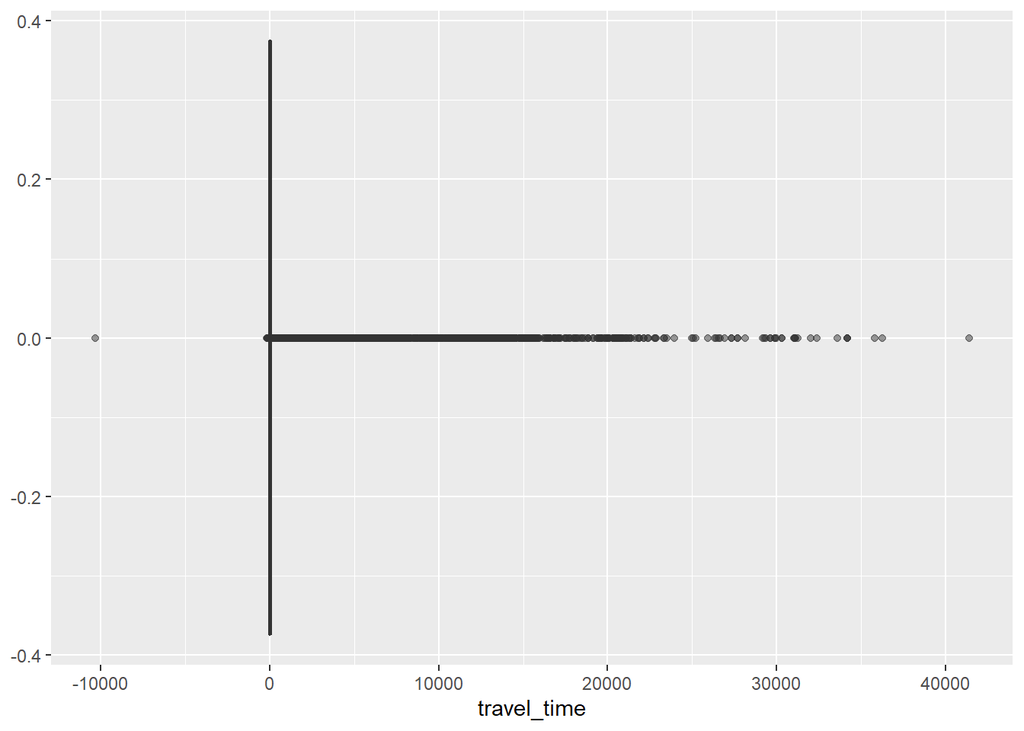

Figure 1: Boxplot of travel time in minutes

```r
bike_rides_raw |>
  ggplot(aes(travel_time)) +
  geom_boxplot(show.legend = F, alpha = .5)
```

Our boxplot shows some extreme values. Let’s take a closer look!

```r
summary(bike_rides_raw$travel_time)
```

```
     Min.   1st Qu.    Median      Mean   3rd Qu.      Max.
-10353.35      5.68     10.03     18.98     18.02  41387.25
```

The minimum and maximum values show that there are unrealistic values at both extremes.

### Failed trips

Filtering for negative travel times and extremely short trips:

```r
failed_trips <- filter(bike_rides_raw, travel_time <= 1)

nrow(failed_trips)
```

```
[1] 134126
```

Dropping failed trips:

```r
bike_rides_raw <- filter(bike_rides_raw, travel_time > 1)
```

### Extremely long trips

The 28-day bike rental also seems quite extreme.

Filtering for extremely long trips:

```r
outliers <- filter(bike_rides_raw, travel_time > 1440)

setDT(outliers)

nrow(outliers)
```

```
[1] 5309
```

On Divvy’s website, you can find what rules apply if you keep a bike out for longer than the time included in your membership or pass:

> *Day Pass holders: unlimited number of 3 hour rides over a 24-hour period. If you keep a bike out for longer than 3 hours at a time, you will be charged an extra $0.17 for each additional minute.*

> *Annual Members: the first 45 minutes of each ride are included in the membership price. If you keep a bike out for longer than 45 minutes at a time, you will be charged an extra $0.17 for each additional minute.*

> *NOTE: If you do not return a bike within a 24-hour period, you may be charged a lost or stolen bike fee of $250 (plus tax).*

This means that bicycles kept out for more than one day can be considered outliers.

Dropping outliers:

```r
bike_rides_raw <- filter(bike_rides_raw, travel_time <= 1440)
```

### Maintenance-related trips

Filtering service trips:

```r
warehouse_trips <- bike_rides_raw |>
  filter(start_station_name %in% c(
    "Base - 2132 W Hubbard Warehouse",
    "DIVVY CASSETTE REPAIR MOBILE STATION",
    "Hastings LWS",
    "NewHastings",
    "WEST CHI-WATSON"
  ) |
    end_station_name %in% c(
      "Base - 2132 W Hubbard Warehouse",
      "DIVVY CASSETTE REPAIR MOBILE STATION",
      "Hastings LWS",
      "NewHastings",
      "WEST CHI-WATSON"
    ))

setDT(warehouse_trips)

nrow(warehouse_trips)
```

```
[1] 2098
```

Removing all service trips to/from warehouses or repair stations:

```r
bike_rides_raw <- bike_rides_raw |>
  anti_join(warehouse_trips, join_by(ride_id))
```

Saving deleted cases:

```r
fwrite(failed_trips, "~/R/backup/cyclistic/failed_trips.csv")
fwrite(outliers, "~/R/backup/cyclistic/outliers.csv")
fwrite(warehouse_trips, "~/R/backup/cyclistic/warehouse_trips.csv")
```

## Missing data

Where does the missingness come from?

- Is there a relationship between missing data and other values?
- Is it random or is it systematic?
- Can we find the missing data?

```r
sum(!complete.cases(bike_rides_raw))
```

```
[1] 1266200
```

Percentage of cases with missing values:

```r
pct_miss_case(bike_rides_raw)
```

```
[1] 22.36238
```

Percentage of missing values:

```r
pct_miss(bike_rides_raw)
```

```
[1] 2.914482
```

We have 1,266,200 cases with missing data, which represents 22.36% of the bike trips in our data table. In total, 2.91% of the values are missing.

### Patterns of missingness

Summarizing the missingness in each variable:

```r
miss_var_summary(bike_rides_raw)
```

| variable | n_miss | pct_miss |
| --- | --- | --- |
| end_station_name | 843965 | 14.9052831 |
| end_station_id | 843965 | 14.9052831 |
| start_station_name | 805588 | 14.2275061 |
| start_station_id | 805588 | 14.2275061 |
| end_lat | 681 | 0.0120272 |
| end_lng | 681 | 0.0120272 |
| ride_id | 0 | 0.0000000 |
| bike_type | 0 | 0.0000000 |
| start_time | 0 | 0.0000000 |
| end_time | 0 | 0.0000000 |
| travel_time | 0 | 0.0000000 |
| start_lat | 0 | 0.0000000 |
| start_lng | 0 | 0.0000000 |
| user_type | 0 | 0.0000000 |
| date | 0 | 0.0000000 |
| month | 0 | 0.0000000 |
| day | 0 | 0.0000000 |
| weekday | 0 | 0.0000000 |
| hour | 0 | 0.0000000 |
| time_of_day | 0 | 0.0000000 |

Figure 2: A summary of the missing data

Let’s look at how missingness is distributed across variables:

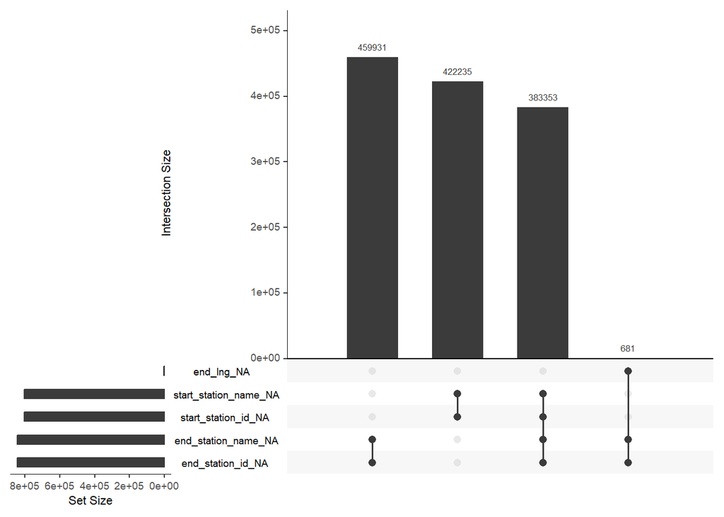

Figure 3: Distribution of missingness across variables

```r
gg_miss_upset(bike_rides_raw)
```

The graph shows four intersections between missing data:

1. group: both end station names and ID-s are missing - 459,931 cases
2. group: both start station names and ID-s are missing - 422,235 cases
3. group: both start and end station names and ID-s are missing - 383,353 cases
4. group: both end station coordinates, names and ID-s are missing - 681 cases

### Missing destination coordinates

- end_lat (n_missing = 681)
- end_lng (n_missing = 681)

Filtering bike trips without destination coordinates:

```r
no_end_coord <- bike_rides_raw |>
  subset(is.na(end_lat) | is.na(end_lng))

setDT(no_end_coord)

nrow(no_end_coord)
```

```
[1] 681
```

Can we link the missing destination coordinates to a specific user group?

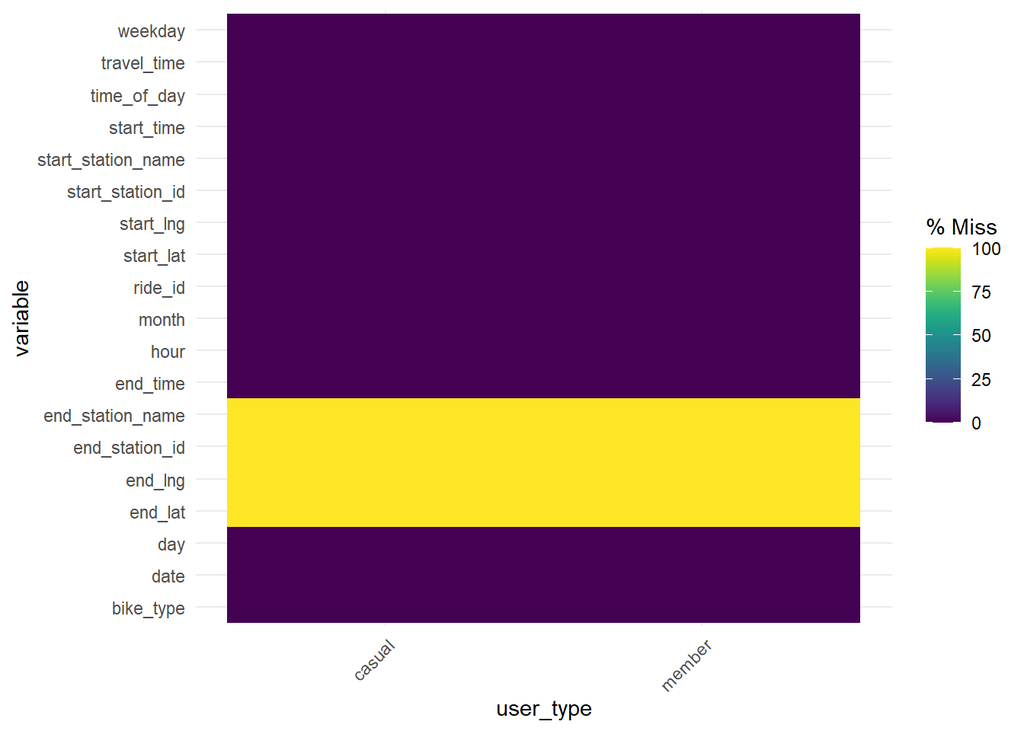

Figure 4: Percentage of missings for each variable, broken down by user type

```r
gg_miss_fct(no_end_coord, user_type)
```

Both groups have the same proportion of missing end station coordinates.

Can we link the missing destination coordinates to a specific bike type?

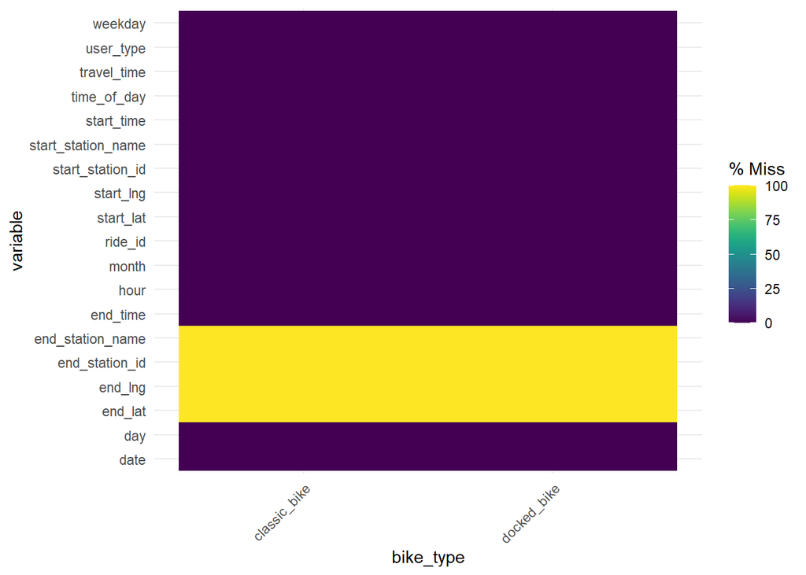

Figure 5: Percentage of missings for each variable, broken down by bike type

```r
gg_miss_fct(no_end_coord, bike_type)
```

The lack of destination coordinates is linked to classic and docked bikes.

Can we link the missing destination coordinates to a specific time period?

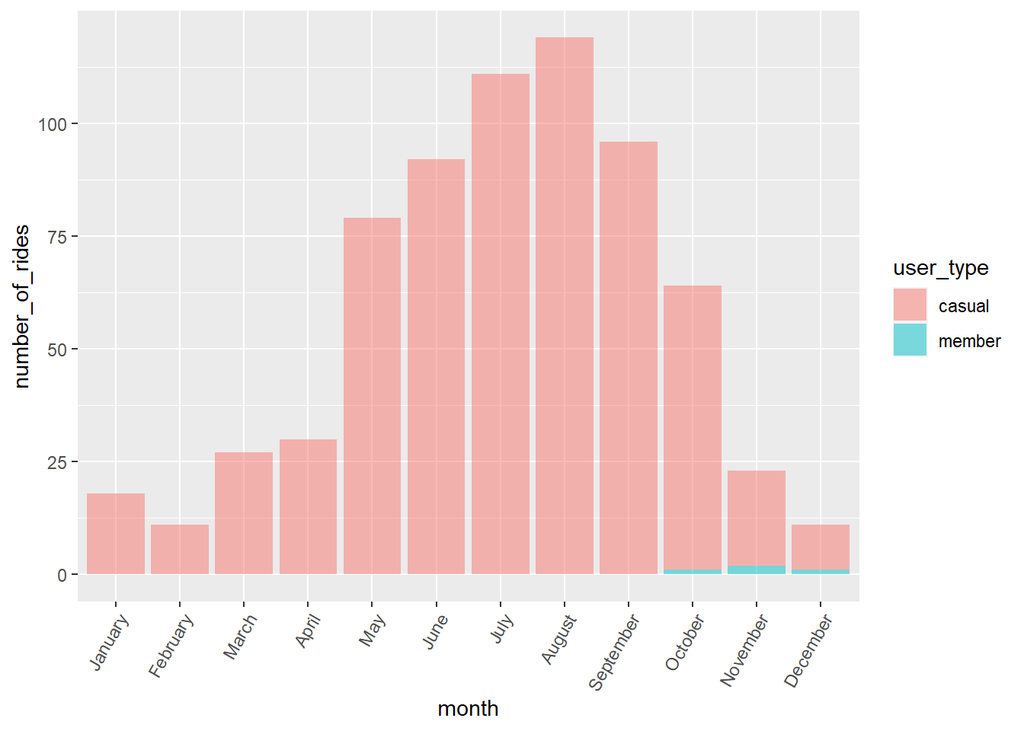

Figure 6: Number of cases with missing data, broken down by month and user type

```r
no_end_coord |>
  group_by(user_type, month) |>
  summarise(
    number_of_rides = n(),
    .groups = "drop_last"
  ) |>
  ggplot(aes(month, number_of_rides, fill = user_type)) +
  geom_col(alpha = .5) +
  theme(
    legend.position = "right",
    legend.direction = "vertical"
  ) +
  theme(axis.text.x = element_text(angle = 60, hjust = 1))
```

We can’t link the missing destination coordinates to a specific time period.

To sum up, we can’t interpret these journeys without knowing where they ended. It is not possible to reconstruct the missing data. For this reason, these cases will be deleted.

Saving for documentation:

```r
fwrite(no_end_coord, "~/R/backup/cyclistic/no_end_coord.csv")
```

Removing all bike trips without destination coordinates:

```r
bike_rides_raw <- bike_rides_raw |>
  anti_join(no_end_coord, join_by(ride_id))
```

### Deleted cases

Summary of the deleted cases:

| Cases | Number of cases |
| --- | --- |
| failed_trips | 134126 |
| outliers | 5309 |
| warehouse_trips | 2098 |
| no_end_coord | 681 |
| **Sum** | **142214** |

```r
nrow(failed_trips) + nrow(outliers) + nrow(warehouse_trips) + nrow(no_end_coord)
```

```
[1] 142214
```

### Filter missings

Filtering cases with missing values:

```r
bike_rides_missing <- bike_rides_raw |>
  filter(!complete.cases(bike_rides_raw))

nrow(bike_rides_missing)
```

```
[1] 1265519
```

At-a-glance ggplot of the missingness:

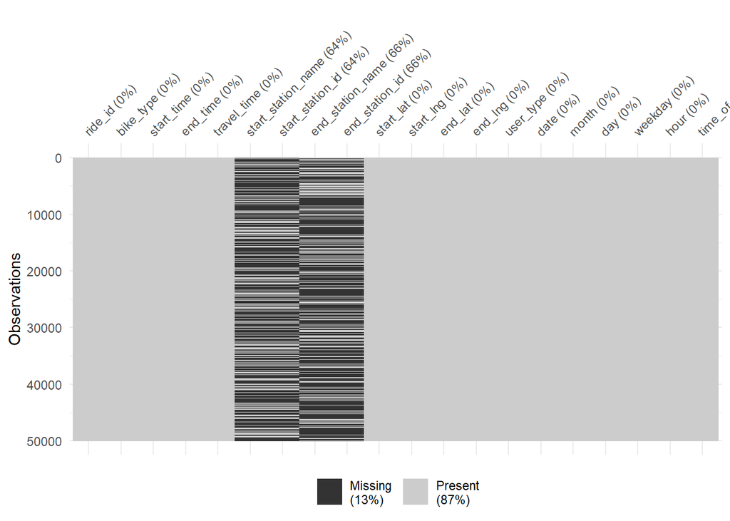

Figure 7: Visual summary of the missing data

```r
vis_miss(slice_sample(bike_rides_missing, n = 50000), warn_large_data = FALSE)

## The size limit for vis_dat and vis_miss functions is 900,000 values,
## which means we can only use a sample of our data for this visualization.
```

### Coordinates

Let’s take a closer look at the coordinates belonging to the missing values.

```r
bike_rides_missing |>
  select(
    start_station_name, start_station_id, end_station_name, end_station_id,
    start_lat, start_lng, end_lat, end_lng
  ) |>
  head(10)
```

| start_station_name | start_station_id | end_station_name | end_station_id | start_lat | start_lng | end_lat | end_lng |
| --- | --- | --- | --- | --- | --- | --- | --- |
| NA | NA | NA | NA | 41.90000 | -87.69000 | 41.91000 | -87.69000 |
| NA | NA | NA | NA | 42.00000 | -87.67000 | 41.98000 | -87.66000 |
| NA | NA | Clark St & Armitage Ave | 13146 | 41.90000 | -87.62000 | 41.91831 | -87.63628 |
| Wells St & Elm St | KA1504000135 | NA | NA | 41.90316 | -87.63478 | 41.92000 | -87.70000 |
| NA | NA | NA | NA | 41.79000 | -87.60000 | 41.79000 | -87.59000 |
| Kimball Ave & Belmont Ave | KA150400009X | NA | NA | 41.93940 | -87.71164 | 41.94000 | -87.76000 |
| NA | NA | NA | NA | 41.79000 | -87.69000 | 41.79000 | -87.71000 |
| NA | NA | Pulaski Rd & 51st St | 343 | 41.80000 | -87.73000 | 41.80000 | -87.72000 |
| NA | NA | NA | NA | 41.89000 | -87.75000 | 41.87000 | -87.75000 |
| Ashland Ave & Division St | 13061 | NA | NA | 41.90343 | -87.66794 | 41.89000 | -87.67000 |

**Observations**

- Where station names are missing, the coordinates have fewer decimals (1-2 digits).
- If you search for these coordinates in the Divvy map, no results are returned.

[figure not shown]

Let’s try to find these coordinates in our stations data:

```r
filter(stations, lat == 41.97 & lng == -87.71)
```

| station_name | station_id | lat | lng |
| --- | --- | --- | --- |
| Public Rack - Kimball Ave & Carmen Ave | 490 | 41.97 | -87.71 |
| Kimball Ave & Carmen Ave | 490 | 41.97 | -87.71 |
| Public Rack - Kedzie Ave & Argyle St | 491 | 41.97 | -87.71 |
| Kedzie Ave & Argyle St | 491 | 41.97 | -87.71 |
| Christiana Ave & Lawrence Ave | 860 | 41.97 | -87.71 |
| Public Rack - Christiana Ave & Lawrence Ave | 860 | 41.97 | -87.71 |
| Public Rack - Sawyer Ave & Lawrence Ave | 861 | 41.97 | -87.71 |
| Sawyer Ave & Lawrence Ave | 861 | 41.97 | -87.71 |

We can find four different stations with four different ID-s at lat = 41.97, lng = -87.71.

**Note**

Degree precision of latitude and longitude coordinates:

Precision can be measured by the number of decimal places in the latitude and longitude coordinates.

To identify stations accurately, we would need coordinates with 4-5 decimal places.

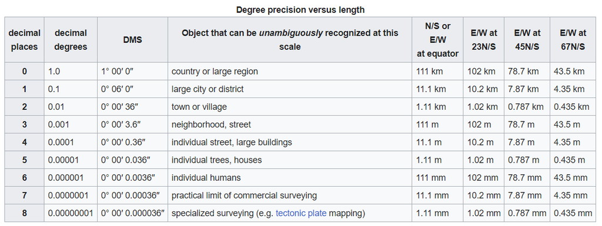

Knowing this, I assume that I won’t be able to reconstruct the missing station names and ID-s.

With 1,265,519 cases concerned, the question is: should I delete all these cases?

First, I filtered out the inaccurate data and now I will check if the missing data can be linked to a specific variable.

My strategy is to delete only those cases that would distort our analysis.

### Investigating the missingness

Can the missing data be linked to a specific time period?

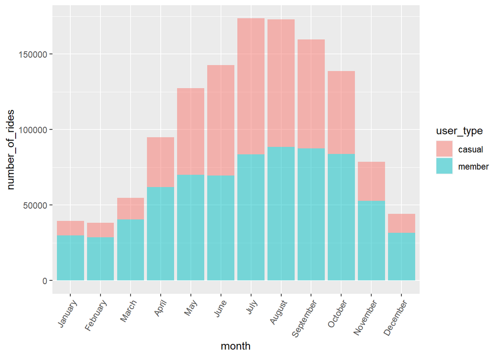

Figure 8: Number of cases with missing data, broken down by month and user type

```r
bike_rides_missing |>
  group_by(user_type, month) |>
  summarise(
    number_of_rides = n(),
    .groups = "drop_last"
  ) |>
  ggplot(aes(month, number_of_rides, fill = user_type)) +
  geom_col(alpha = .5) +
  theme(
    legend.position = "right",
    legend.direction = "vertical"
  ) +
  theme(axis.text.x = element_text(angle = 60, hjust = 1))
```

Our graph shows that the missing data cannot be linked to a specific time period. It appears throughout the year.

Would both groups of users be affected equally if we deleted all rows with missing values?

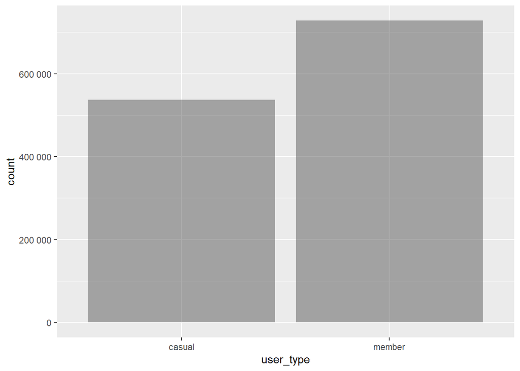

Figure 9: Number of cases with missing data broken down by user type

```r
bike_rides_missing |>
  ggplot(aes(user_type)) +
  geom_bar(alpha = .5) +
  scale_y_continuous(labels = label_number())
```

Both group of users have missing values and members would be slightly more affected than casual users.

Can the missing data be linked to a specific bike type?

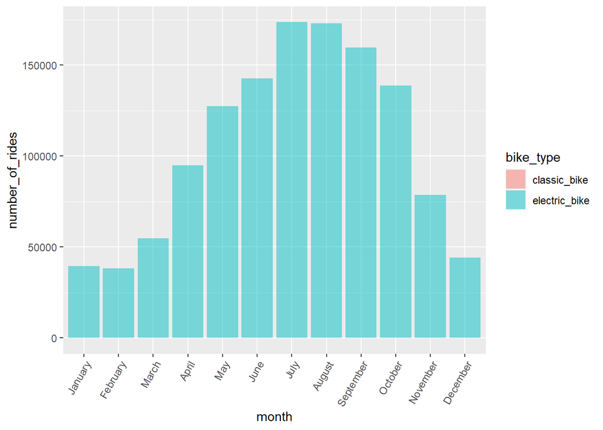

Figure 10: Number of cases with missing values, broken down by bike type

```r
bike_rides_missing |>
  group_by(bike_type, month) |>
  summarise(
    number_of_rides = n(),
    .groups = "drop_last"
  ) |>
  ggplot(aes(month, number_of_rides, fill = bike_type)) +
  geom_col(alpha = .5) +
  theme(axis.text.x = element_text(angle = 60, hjust = 1))
```

There seems to be a clear link between missing data and electric bikes.

After weighing the benefits and risks of deleting all cases with missing values, I decided not to remove these cases from our data table. It is not possible to identify the name of the start or end station of these trips, due to the imprecision of the coordinates, but deleting the more than 1 million observations concerned would bias the subsequent results of the analysis, as the deletion would adversely affect cyclist members and users who choose electric bicycles.

```r
fwrite(bike_rides_missing, "~/R/backup/cyclistic/bike_rides_missing.csv")
```

## Final check

```r
glimpse(bike_rides_raw)
```

```
Rows: 5,661,506
Columns: 20
$ ride_id            <chr> "00000179CF2C4FB5", "0000038F578A7278", "0000047373~
$ bike_type          <fct> electric_bike, electric_bike, electric_bike, electr~
$ start_time         <dttm> 2022-07-28 09:02:27, 2022-12-15 15:36:06, 2022-07-~
$ end_time           <dttm> 2022-07-28 09:13:51, 2022-12-15 15:44:35, 2022-07-~
$ travel_time        <dbl> 11.40, 8.48, 25.20, 14.32, 5.53, 12.50, 4.80, 11.13~
$ start_station_name <chr> "Ellis Ave & 55th St", "Lakeview Ave & Fullerton Pk~
$ start_station_id   <chr> "KA1504000076", "TA1309000019", "13022", "13193", N~
$ end_station_name   <chr> "Ellis Ave & 55th St", "Clark St & Elm St", "Calume~
$ end_station_id     <chr> "KA1504000076", "TA1307000039", "13102", "TA1305000~
$ start_lat          <dbl> 41.79424, 41.92583, 41.89221, 41.92185, 41.90000, 4~
$ start_lng          <dbl> -87.60134, -87.63882, -87.61183, -87.64402, -87.690~
$ end_lat            <dbl> 41.79430, 41.90297, 41.85761, 41.90312, 41.91000, 4~
$ end_lng            <dbl> -87.60145, -87.63128, -87.61941, -87.67394, -87.690~
$ user_type          <fct> casual, casual, casual, casual, member, casual, mem~
$ date               <date> 2022-07-28, 2022-12-15, 2022-07-22, 2022-07-17, 20~
$ month              <ord> July, December, July, July, July, June, August, May~
$ day                <int> 28, 15, 22, 17, 2, 12, 4, 19, 2, 12, 25, 13, 15, 19~
$ weekday            <ord> Thursday, Thursday, Friday, Sunday, Saturday, Sunda~
$ hour               <int> 9, 15, 16, 13, 20, 5, 22, 14, 12, 10, 10, 18, 18, 2~
$ time_of_day        <ord> Late morning, Late afternoon, Late afternoon, Early~
```

Taking a peak at column names:

```r
colnames(bike_rides_raw)
```

```
 [1] "ride_id"            "bike_type"          "start_time"
 [4] "end_time"           "travel_time"        "start_station_name"
 [7] "start_station_id"   "end_station_name"   "end_station_id"
[10] "start_lat"          "start_lng"          "end_lat"
[13] "end_lng"            "user_type"          "date"
[16] "month"              "day"                "weekday"
[19] "hour"               "time_of_day"
```

Selecting and reordering variables:

```r
bike_rides_clean <- subset(
  bike_rides_raw,
  select = c(
    "ride_id", "user_type", "bike_type",
    "travel_time", "date", "month", "day",
    "weekday", "hour", "time_of_day",
    "start_station_name", "end_station_name",
    "start_lat", "start_lng", "end_lat", "end_lng"
  )
)
```

Changing data types:

```r
bike_rides_clean$start_station_name <- as.factor(bike_rides_clean$start_station_name)
bike_rides_clean$end_station_name <- as.factor(bike_rides_clean$end_station_name)
```

Saving clean data:

```r
fwrite(bike_rides_clean, "~/R/backup/cyclistic/bike_rides_clean.csv")
```

Removing data tables to free up memory:

```r
rm(
  failed_trips,
  outliers,
  warehouse_trips,
  no_end_coord,
  bike_rides_missing,
  start_stations,
  end_stations
)
```

# Data Analysis

The analysis covers **5,661,506 bike rides** between **1 April 2022** and **31 March 2023**.

## Limitations of the data

**Note**

The data has some limitations due to protection of user privacy:

- We lack demographic data.
- This means we can’t tell if a user is a local resident or a visitor.
- Likewise, we can’t link different bike rides to the same user.
- We don’t know how many unique users are in the database.
- We can’t tell how many bike trips can be linked to the same user.
- We can’t tell if a casual user has bought a single ride pass or a day pass.
- Due to the imprecision of the coordinates, we have 1 265 519 cases with incomplete station identification.

## Descriptive analysis

```r
summary(bike_rides_clean)
```

```
   ride_id           user_type               bike_type        travel_time
 Length:5661506     casual:2280849   classic_bike :2596597   Min.   :   1.02
 Class :character   member:3380657   docked_bike  : 169551   1st Qu.:   5.93
 Mode  :character                    electric_bike:2895358   Median :  10.27
                                                             Mean   :  16.21
                                                             3rd Qu.:  18.27
                                                             Max.   :1439.37

      date                  month              day             weekday
 Min.   :2022-04-01   July     : 804092   Min.   : 1.00   Monday   :741862
 1st Qu.:2022-06-18   August   : 766881   1st Qu.: 8.00   Tuesday  :795886
 Median :2022-08-13   June     : 752293   Median :16.00   Wednesday:803285
 Mean   :2022-08-24   September: 684588   Mean   :15.73   Thursday :841694
 3rd Qu.:2022-10-14   May      : 621419   3rd Qu.:23.00   Friday   :810410
 Max.   :2023-03-31   October  : 544927   Max.   :31.00   Saturday :900717
                      (Other)  :1487306                   Sunday   :767652
      hour               time_of_day
 Min.   : 0.0   Late afternoon :1460418
 1st Qu.:11.0   Early evening  :1088148
 Median :15.0   Early afternoon:1005958
 Mean   :14.2   Late morning   : 731521
 3rd Qu.:18.0   Early morning  : 633498
 Max.   :23.0   Late evening   : 498286
                (Other)        : 243677
                          start_station_name
 Streeter Dr & Grand Ave           :  72448
 DuSable Lake Shore Dr & Monroe St :  39803
 Michigan Ave & Oak St             :  38761
 DuSable Lake Shore Dr & North Blvd:  38704
 Wells St & Concord Ln             :  37647
 (Other)                           :4628555
 NA's                              : 805588
                           end_station_name     start_lat       start_lng
 Streeter Dr & Grand Ave           :  73114   Min.   :41.64   Min.   :-87.84
 DuSable Lake Shore Dr & North Blvd:  41101   1st Qu.:41.88   1st Qu.:-87.66
 Michigan Ave & Oak St             :  39301   Median :41.90   Median :-87.64
 DuSable Lake Shore Dr & Monroe St :  38651   Mean   :41.90   Mean   :-87.65
 Wells St & Concord Ln             :  37788   3rd Qu.:41.93   3rd Qu.:-87.63
 (Other)                           :4588267   Max.   :42.07   Max.   :-87.52
 NA's                              : 843284
    end_lat         end_lng
 Min.   :41.55   Min.   :-88.14
 1st Qu.:41.88   1st Qu.:-87.66
 Median :41.90   Median :-87.64
 Mean   :41.90   Mean   :-87.65
 3rd Qu.:41.93   3rd Qu.:-87.63
 Max.   :42.37   Max.   :-87.30
```

### Travel time

```r
find_mode <- function(x) {
  u <- unique(x)
  tab <- tabulate(match(x, u))
  u[tab == max(tab)]
}
```

```r
min(bike_rides_clean$travel_time) # shortest ride
```

```
[1] 1.02
```

```r
max(bike_rides_clean$travel_time) # longest ride
```

```
[1] 1439.37
```

```r
mean(bike_rides_clean$travel_time) # straight average (total travel time / rides)
```

```
[1] 16.212
```

```r
median(bike_rides_clean$travel_time) # midpoint number in the ascending array of travel times
```

```
[1] 10.27
```

```r
find_mode(bike_rides_clean$travel_time) # the value that occurs most often
```

```
[1] 5.38
```

```r
sd(bike_rides_clean$travel_time) # standard deviation (how dispersed the data is in relation to the mean)
```

```
[1] 28.42452
```

- Shortest ride: 1.02 min.
- Longest ride: 1439.37 min.
- Average ride: 16.212 min.
- Median: 10.27 min.
- Mode: 5.38 min.
- Standard deviation: 28.42452 min.

## Comparing members and casual users

### Number of rides

```r
bike_rides_clean |>
  count(user_type, sort = T)
```

Table 1: Number of rides per user group between 1 April 2022 and 31 March 2023

| user_type | n |
| --- | --- |
| member | 3380657 |
| casual | 2280849 |

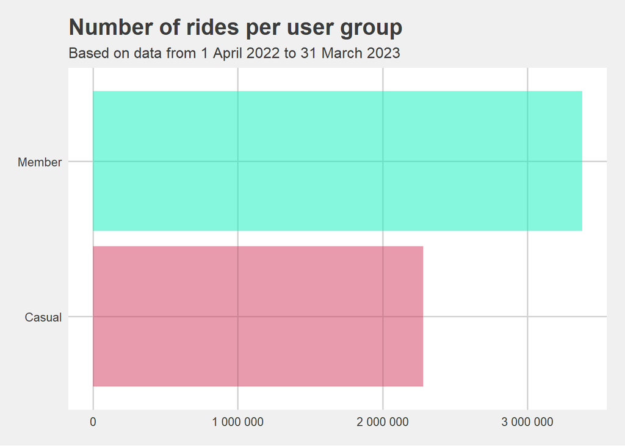

Figure 11: Total number of bike rides per year

```r
bike_rides_clean |>
  group_by(user_type) |>
  summarise(number_of_rides = n(), .groups = "drop_last") |>
  ggplot(aes(number_of_rides, user_type, fill = user_type)) +
  geom_bar(
    stat = "identity",
    alpha = .5
  ) +
  scale_fill_manual(
    values = c("#cf385b", "#0CF0BB"),
    labels = c("Casual", "Member")
  ) +
  scale_x_continuous(labels = label_number()) +
  scale_y_discrete(labels = c("Casual", "Member")) +
  theme_fivethirtyeight() +
  theme(
    panel.background = element_rect(fill = "white"),
    legend.position = "none"
  ) +
  labs(
    title = "Number of rides per user group",
    subtitle = "Based on data from 1 April 2022 to 31 March 2023"
  )
```

Between 1 April 2022 and 31 March 2023, casual users made 2,280,849 bike rentals, while members used the bike sharing service 3,380,657 times.

**Note**

As mentioned above, due to protection of user privacy, we can’t link different bike trips to the same user, so we can’t say how many trips one user makes on average during different time units.

### Bike preferences

```r
bike_rides_clean |>
  group_by(user_type, bike_type) |>
  summarise(
    number_of_rides = n(),
    percentage = round(100 * n() / nrow(bike_rides_clean), 1),
    .groups = "drop_last"
  ) |>
  arrange(desc(percentage))
```

Table 2: Bike preference in numbers

| user_type | bike_type | number_of_rides | percentage |
| --- | --- | --- | --- |
| member | classic_bike | 1722307 | 30.4 |
| member | electric_bike | 1658350 | 29.3 |
| casual | electric_bike | 1237008 | 21.8 |
| casual | classic_bike | 874290 | 15.4 |
| casual | docked_bike | 169551 | 3.0 |

```r
bike_rides_clean |>
  group_by(user_type) |>
  mutate(user_count = n()) |>
  group_by(bike_type, user_count, .add = TRUE) |>
  summarise(
    bike_count = n(),
    bike_pctg = round(bike_count / first(user_count) * 100, 1),
    .groups = "drop_last"
  )
```

Table 3: Bike preference with sub-group percentages

| user_type | bike_type | user_count | bike_count | bike_pctg |
| --- | --- | --- | --- | --- |
| casual | classic_bike | 2280849 | 874290 | 38.3 |
| casual | docked_bike | 2280849 | 169551 | 7.4 |
| casual | electric_bike | 2280849 | 1237008 | 54.2 |
| member | classic_bike | 3380657 | 1722307 | 50.9 |
| member | electric_bike | 3380657 | 1658350 | 49.1 |

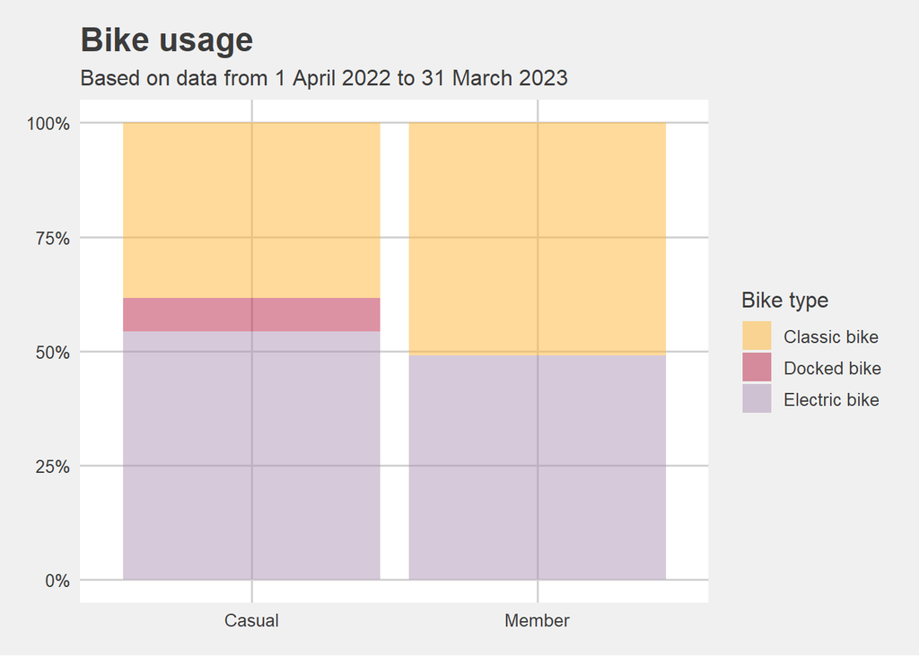

Figure 12: Bike preferences

```r
bike_rides_clean |>
  ggplot(aes(user_type, fill = bike_type)) +
  geom_bar(
    position = "fill",
    alpha = .5
  ) +
  scale_fill_manual(
    name = "Bike type",
    values = c("#ffb635", "#bb2649", "#ad93b4"),
    labels = c("Classic bike", "Docked bike", "Electric bike")
  ) +
  scale_y_continuous(labels = label_percent()) +
  scale_x_discrete(labels = c("Casual", "Member")) +
  theme_fivethirtyeight() +
  theme(
    panel.background = element_rect(fill = "white"),
    legend.position = "right",
    legend.direction = "vertical"
  ) +
  labs(
    title = "Bike usage",
    subtitle = "Based on data from 1 April 2022 to 31 March 2023"
  )
```

### Average travel times

```r
bike_rides_clean |>
  group_by(user_type) |>
  summarise(average_travel_time = mean(travel_time)) |>
  ungroup()
```

Table 4: Average time spent cycling

| user_type | average_travel_time |
| --- | --- |
| casual | 21.75334 |
| member | 12.47338 |

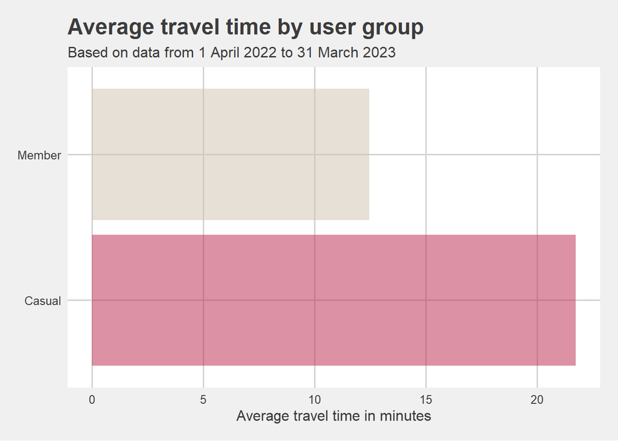

Figure 13: Average travel time by user groups

```r
bike_rides_clean |>
  group_by(user_type) |>
  summarise(average_travel_time = mean(travel_time)) |>
  ggplot(aes(average_travel_time, user_type, fill = user_type)) +
  geom_col(alpha = .5) +
  scale_fill_manual(
    values = c("#BA2649", "#CEC2AE"),
    labels = c("Casual", "Member")
  ) +
  scale_y_discrete(labels = c("Casual", "Member")) +
  theme_fivethirtyeight() +
  theme(
    panel.background = element_rect(fill = "white"),
    legend.position = "none",
    axis.title.x = element_text()
  ) +
  labs(
    title = "Average travel time by user group",
    subtitle = "Based on data from 1 April 2022 to 31 March 2023"
  ) +
  xlab("Average travel time in minutes")
```

Members spend an average of 12.47 minutes on their bikes, while casual users cycle for an average of 21.75 minutes. The difference in average travel time between the two groups is 9.28 minutes.

### Cycling habits throughout the year

```r
bike_rides_clean |>
  group_by(user_type, date) |>
  summarise(number_of_rides = n(), .groups = "drop_last") |>
  arrange(desc(number_of_rides)) |>
  head()
```

Table 5: Cycling habits throughout the year

| user_type | date | number_of_rides |
| --- | --- | --- |
| casual | 2022-05-29 | 20631 |
| casual | 2022-07-09 | 20462 |
| casual | 2022-04-23 | 19828 |
| casual | 2022-06-18 | 19781 |
| casual | 2022-06-26 | 19034 |
| casual | 2022-07-30 | 18942 |

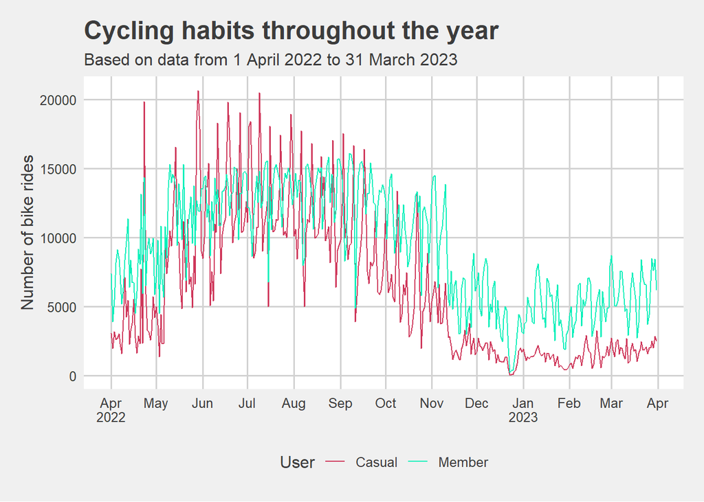

Figure 14: Number of rides over the course of one year

```r
bike_rides_clean |>
  group_by(user_type, date) |>
  summarise(number_of_rides = n(), .groups = "drop_last") |>
  ggplot(aes(date, number_of_rides, color = user_type)) +
  geom_line() +
  scale_color_manual(
    name = "User",
    values = c("#cf385b", "#0CF0BB"),
    labels = c("Casual", "Member")
  ) +
  scale_x_date(
    breaks = breaks_width("1 month"),
    limits = c(as.Date("2022-04-01"), as.Date("2023-03-31")),
    labels = label_date_short()
  ) +
  theme_fivethirtyeight() +
  theme(
    panel.background = element_rect(fill = "white"),
    legend.position = "bottom",
    legend.direction = "horizontal",
    axis.title.y = element_text()
  ) +
  labs(
    title = "Cycling habits throughout the year",
    subtitle = "Based on data from 1 April 2022 to 31 March 2023"
  ) +
  ylab("Number of bike rides")
```

Both groups showed fairly similar cycling patterns over the past year. As expected, the increase in numbers followed the change of the seasons with members starting more bike rides in the colder months than casuals.

### Cycling patterns during the week

```r
bike_rides_clean |>
  group_by(user_type, weekday) |>
  summarise(
    number_of_rides = n(),
    average_travel_time = mean(travel_time),
    .groups = "drop_last"
  ) |>
  arrange(desc(average_travel_time))
```

Table 6: Cycling patterns during the week

| user_type | weekday | number_of_rides | average_travel_time |
| --- | --- | --- | --- |
| casual | Sunday | 379877 | 24.95871 |
| casual | Saturday | 460053 | 24.53749 |
| casual | Monday | 269074 | 21.96020 |
| casual | Friday | 332735 | 20.56553 |
| casual | Tuesday | 264714 | 19.51056 |
| casual | Thursday | 304307 | 19.45462 |
| casual | Wednesday | 270089 | 18.54802 |
| member | Saturday | 440664 | 13.95836 |
| member | Sunday | 387775 | 13.82034 |
| member | Friday | 477675 | 12.28601 |
| member | Thursday | 537387 | 12.08078 |
| member | Monday | 472788 | 11.97773 |
| member | Tuesday | 531172 | 11.87641 |
| member | Wednesday | 533196 | 11.86427 |

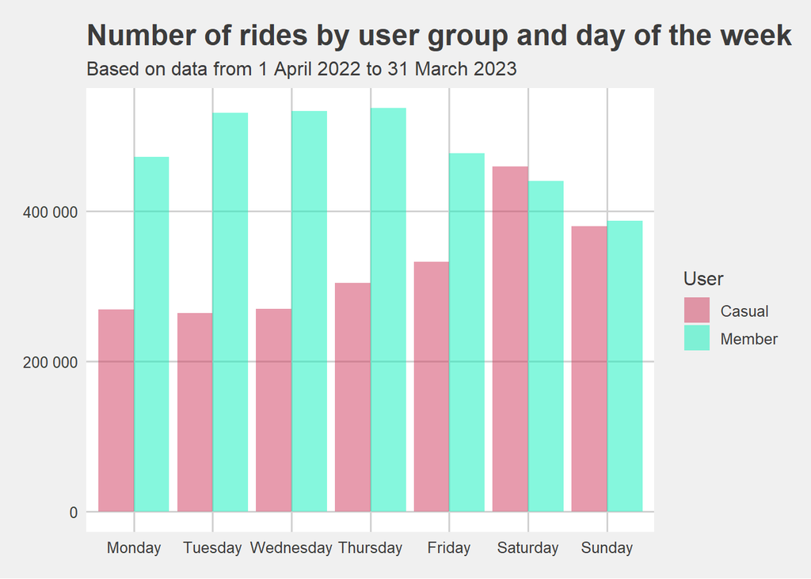

Figure 15: Cycling patterns during the week

```r
bike_rides_clean |>
  group_by(user_type, weekday) |>
  summarise(
    number_of_rides = n(),
    .groups = "drop_last"
  ) |>
  ggplot(aes(weekday, number_of_rides, fill = user_type)) +
  geom_col(position = "dodge", alpha = .5) +
  scale_fill_manual(
    values = c("#cf385b", "#0CF0BB"),
    labels = c("Casual", "Member"),
    name = "User"
  ) +
  scale_y_continuous(labels = label_number()) +
  theme_fivethirtyeight() +
  theme(
    panel.background = element_rect(fill = "white"),
    legend.position = "right",
    legend.direction = "vertical"
  ) +
  labs(
    title = "Number of rides by user group and day of the week",
    subtitle = "Based on data from 1 April 2022 to 31 March 2023"
  )
```

The graph shows a clear difference between the two groups: Members use the service more on weekdays, with peak usage on Tuesday, Wednesday and Thursday, and a decrease from Friday onwards.

In contrast, casual users tend to make more trips from Thursday onwards and peak on the weekend.

### Daily average travel time

```r
bike_rides_clean |>
  group_by(user_type, weekday) |>
  summarise(
    number_of_rides = n(),
    average_travel_time = mean(travel_time),
    .groups = "drop_last"
  ) |>
  arrange(desc(average_travel_time))
```

Table 7: Average travel time by day of the week

| user_type | weekday | number_of_rides | average_travel_time |
| --- | --- | --- | --- |
| casual | Sunday | 379877 | 24.95871 |
| casual | Saturday | 460053 | 24.53749 |
| casual | Monday | 269074 | 21.96020 |
| casual | Friday | 332735 | 20.56553 |
| casual | Tuesday | 264714 | 19.51056 |
| casual | Thursday | 304307 | 19.45462 |
| casual | Wednesday | 270089 | 18.54802 |
| member | Saturday | 440664 | 13.95836 |
| member | Sunday | 387775 | 13.82034 |
| member | Friday | 477675 | 12.28601 |
| member | Thursday | 537387 | 12.08078 |
| member | Monday | 472788 | 11.97773 |
| member | Tuesday | 531172 | 11.87641 |
| member | Wednesday | 533196 | 11.86427 |

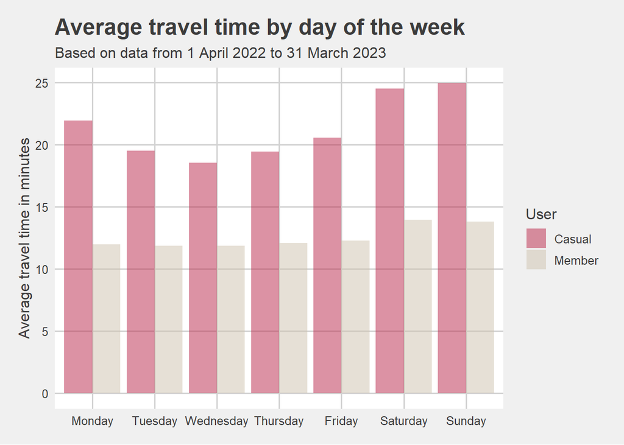

Figure 16: Average travel time by day of the week

```r
bike_rides_clean |>
  group_by(user_type, weekday) |>
  summarise(
    number_of_rides = n(),
    average_travel_time = mean(travel_time),
    .groups = "drop_last"
  ) |>
  ggplot(aes(weekday, average_travel_time, fill = user_type)) +
  geom_col(position = "dodge", alpha = .5) +
  scale_fill_manual(
    values = c("#BA2649", "#CEC2AE"),
    labels = c("Casual", "Member"),
    name = "User"
  ) +
  scale_y_continuous(
    labels = label_number(),
  ) +
  theme_fivethirtyeight() +
  theme(
    panel.background = element_rect(fill = "white"),
    legend.position = "right",
    legend.direction = "vertical",
    axis.title = element_text(),
    axis.title.x = element_blank()
  ) +
  labs(
    title = "Average travel time by day of the week",
    subtitle = "Based on data from 1 April 2022 to 31 March 2023"
  ) +
  ylab("Average travel time in minutes")
```

We already saw that members make more trips than casual users but they spend less time on their bikes, while casuals do the opposite, they start less rides, but spend more time cycling.

We can also spot that the average travel time for members is fairly consistent, with no major fluctuations throughout the week, while casuals have a bigger rise in their average times at weekends and on Mondays.

### Time of the day

```r
bike_rides_clean |>
  group_by(time_of_day, user_type) |> # groups by user type and time of day
  summarise(
    number_of_rides = n(),
    .groups = "drop_last"
  ) |> # calculates the number of rides
  arrange(desc(number_of_rides)) # sorts by number of rides
```

Table 8: Cycling habits by time of day

| time_of_day | user_type | number_of_rides |
| --- | --- | --- |
| Late afternoon | member | 875232 |
| Early evening | member | 637987 |
| Late afternoon | casual | 585186 |
| Early afternoon | member | 561105 |
| Early morning | member | 480586 |
| Early evening | casual | 450161 |
| Late morning | member | 448281 |
| Early afternoon | casual | 444853 |
| Late morning | casual | 283240 |
| Late evening | member | 257370 |
| Late evening | casual | 240916 |
| Early morning | casual | 152912 |
| Night | casual | 92847 |
| Night | member | 71207 |
| Dawn | member | 48889 |
| Dawn | casual | 30734 |

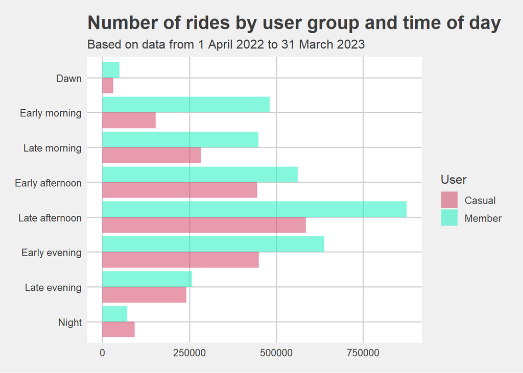

Figure 17: Cycling habits by time of day

```r
bike_rides_clean |>
  group_by(time_of_day, user_type) |>
  summarise(
    number_of_rides = n(),
    .groups = "drop_last"
  ) |>
  ggplot(aes(
    number_of_rides,
    time_of_day,
    fill = user_type
  )) +
  geom_col(position = "dodge", alpha = .5) +
  scale_fill_manual(
    values = c("#cf385b", "#0CF0BB"),
    labels = c("Casual", "Member"),
    name = "User"
  ) +
  scale_y_discrete(
    limits = rev(levels(bike_rides_clean$time_of_day))
  ) +
  theme_fivethirtyeight() +
  theme(
    panel.background = element_rect(fill = "white"),
    legend.position = "right",
    legend.direction = "vertical"
  ) +
  labs(
    title = "Number of rides by user group and time of day",
    subtitle = "Based on data from 1 April 2022 to 31 March 2023"
  )
```

This graph shows how cycling activity change throughout the day. Late afternoon (15:00-18:00) is when most people from both groups get on their bikes.  
One might think that the majority of members would cycle to work in the morning and then cycle home in the afternoon, but our data suggest that morning cycling is far less popular than afternoon cycling.

Unlike members, casual users prefer to skip the early morning rush (6:00-9:00) and cycle in the afternoon and evening hours instead.

### Average travel time by time of day

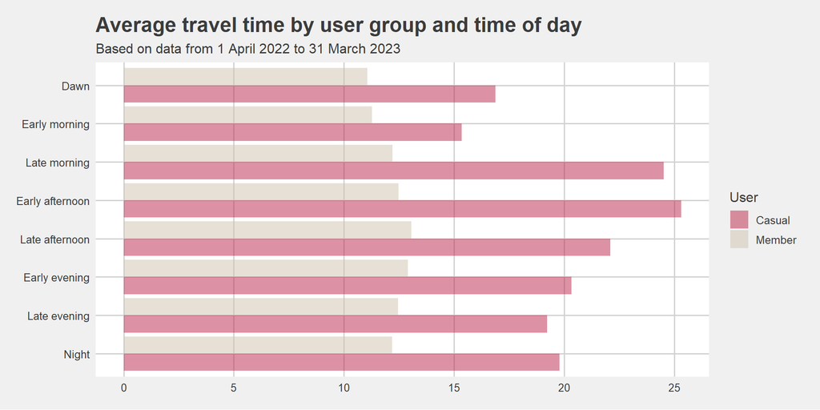

Figure 18: Average travel time by time of day

```r
bike_rides_clean |>
  group_by(time_of_day, user_type) |>
  summarise(
    average_travel_time = mean(travel_time),
    .groups = "drop_last"
  ) |>
  ggplot(aes(
    average_travel_time,
    time_of_day,
    fill = user_type
  )) +
  geom_col(position = "dodge", alpha = .5) +
  scale_fill_manual(
    values = c("#BA2649", "#CEC2AE"),
    labels = c("Casual", "Member"),
    name = "User"
  ) +
  scale_y_discrete(
    limits = rev(levels(bike_rides_clean$time_of_day))
  ) +
  theme_fivethirtyeight() +
  theme(
    panel.background = element_rect(fill = "white"),
    legend.position = "right",
    legend.direction = "vertical"
  ) +
  labs(
    title = "Average travel time by user group and time of day",
    subtitle = "Based on data from 1 April 2022 to 31 March 2023"
  ) +
  xlab("Average travel time in minutes")
```

The average travel time of members remains roughly the same regardless of the time of day, while the average cycling time of casual users varies more depending on the time of day. Casuals start their longest rides in late morning and early afternoon.

### Number of rides per hour started

```r
bike_rides_clean |>
  group_by(hour, user_type) |> # groups by user type and hour
  summarise(
    number_of_rides = n(),
    .groups = "drop_last"
  ) |> # calculates the number of rides
  arrange(desc(number_of_rides)) |> # sorts by number of rides
  head()
```

Table 9: Number of rides per hour started

| hour | user_type | number_of_rides |
| --- | --- | --- |
| 17 | member | 354753 |
| 16 | member | 296099 |
| 18 | member | 285994 |
| 15 | member | 224380 |
| 17 | casual | 216029 |
| 8 | member | 210792 |

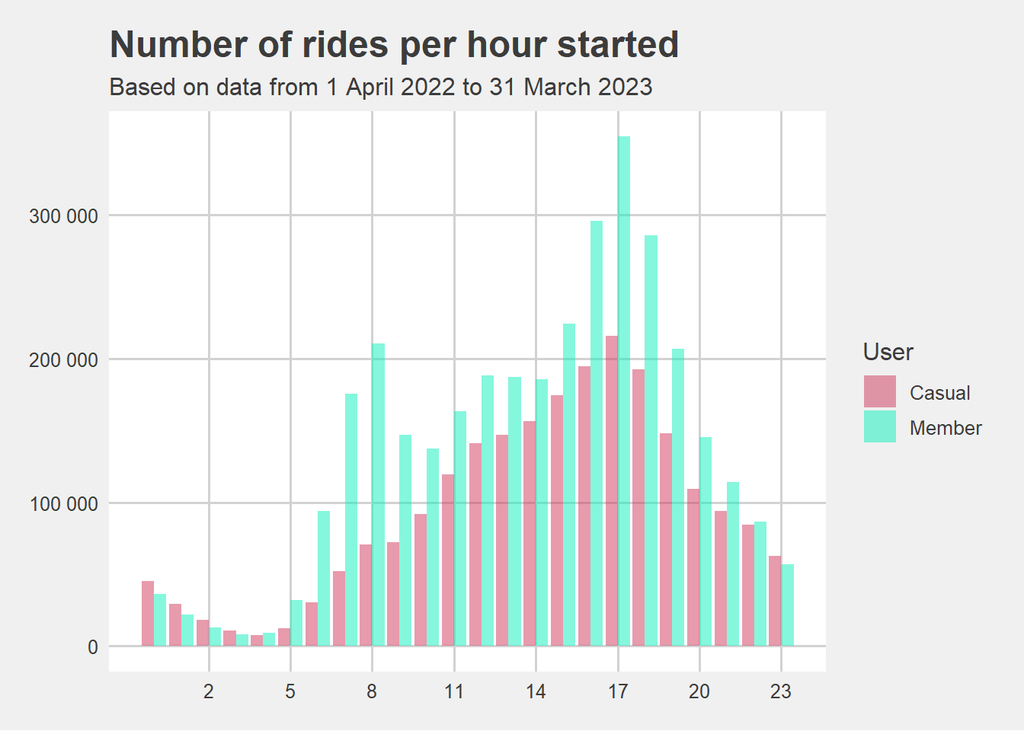

Figure 19: Number of rides per hour started

```r
bike_rides_clean |>
  group_by(user_type, hour) |>
  summarise(
    number_of_rides = n(),
    .groups = "drop_last"
  ) |>
  ggplot(aes(hour, number_of_rides, fill = user_type)) +
  geom_col(position = "dodge", alpha = .5) +
  scale_fill_manual(
    values = c("#cf385b", "#0CF0BB"),
    labels = c("Casual", "Member"),
    name = "User"
  ) +
  scale_x_continuous(breaks = c(2, 5, 8, 11, 14, 17, 20, 23)) +
  scale_y_continuous(labels = label_number()) +
  theme_fivethirtyeight() +
  theme(
    panel.background = element_rect(fill = "white"),
    legend.position = "right",
    legend.direction = "vertical"
  ) +
  labs(
    title = "Number of rides per hour started",
    subtitle = "Based on data from 1 April 2022 to 31 March 2023"
  )
```

The peak hour of the day is around 17:00 for both groups, but members also have a morning peak around 8:00. From late afternoon to early morning, both groups show a similar pattern of decreasing numbers of departures.

### Stations with the most traffic

Ranking the most popular departure stations:

```r
stations_popularity <- bike_rides_clean |>
  count(user_type, start_station_name, start_lat, start_lng, sort = T)

stations_pop_sample <- stations_popularity[1:100, ]

summary(stations_pop_sample$n)
```

```
   Min. 1st Qu.  Median    Mean 3rd Qu.    Max.
   6798    7638    8381    9585    9942   38940
```

Getting user group specific data:

```r
member_stations <- stations_popularity |>
  filter(user_type == "member")

member_stations <- member_stations[1:100, ]

casual_stations <- stations_popularity |>
  filter(user_type == "casual")

casual_stations <- casual_stations[1:100, ]
```

Defining labels:

```r
text_c <- paste(
  "Station: ", casual_stations$start_station_name, "<br/>",
  "Departures: ", casual_stations$n, "<br/>",
  sep = ""
) |>
  lapply(htmltools::HTML)

text_m <- paste(
  "Station: ", member_stations$start_station_name, "<br/>",
  "Departures: ", member_stations$n, "<br/>",
  sep = ""
) |>
  lapply(htmltools::HTML)
```

The busiest departure stations by user groups:

```r
map <- leaflet() |>
  clearBounds() |>
  addTiles() |>
  addCircles(
    data = casual_stations,
    lng = ~start_lng,
    lat = ~start_lat,
    weight = 1,
    radius = ~ sqrt(n),
    stroke = 3,
    color = "white",
    fillColor = "#ff0984",
    fillOpacity = 0.7,
    label = text_c,
    group = "Casual",
    highlightOptions = highlightOptions(
      color = "#ffb4d1",
      weight = 3,
      stroke = 6,
      bringToFront = TRUE,
      opacity = 1
    )
  ) |>
  addCircles(
    data = member_stations,
    lng = ~start_lng,
    lat = ~start_lat,
    weight = 1,
    radius = ~ sqrt(n),
    stroke = 3,
    color = "white",
    fillColor = "#21409a",
    fillOpacity = 0.7,
    label = text_m,
    group = "Member",
    highlightOptions = highlightOptions(
      color = "#04adff",
      weight = 3,
      stroke = 6,
      bringToFront = TRUE,
      opacity = 1
    )
  ) |>
  addLayersControl(
    overlayGroups = c("Casual", "Member"),
    options = layersControlOptions(collapsed = FALSE)
  )
```

Visualization:

```r
map
```

[interactive chart not shown]

(a) Zoom and hover to see the station name and number of departures. Select the user group by ticking the boxes in the top right hand corner.

Figure 20: Busiest departure stations between 1 April 2022 and 31 March 2023

A compilation of the 100 most visited stations by members and casual users:

```r
library(dplyr)

top_stations <- bind_rows(member_stations, casual_stations)

summary(top_stations$n)
```

```
   Min. 1st Qu.  Median    Mean 3rd Qu.    Max.
   3467    4814    6791    7308    8380   38940
```

Creating a color palette with handmade bins:

```r
my_bins <- seq(3000, 39000, by = 6000)
my_palette <- colorBin(
  palette = "plasma", domain = top_stations$n, na.color = "white",
  bins = my_bins
)
```

The 100 busiest departure stations for casual users:

```r
c_map <- leaflet(casual_stations) |>
  clearBounds() |>
  addTiles() |>
  addCircles(
    lng = ~start_lng,
    lat = ~start_lat,
    weight = 1,
    radius = ~ sqrt(n),
    fillColor = ~ my_palette(n),
    fillOpacity = 0.8,
    stroke = TRUE,
    label = text_c
  ) |>
  addLegend(
    "bottomright",
    pal = my_palette,
    values = ~n,
    title = "Number of departures",
    opacity = 1
  )
```

Visualization:

```r
c_map
```

[interactive chart not shown]

(a) Zoom and hover to see the station name and number of departures

Figure 21: The 100 most popular departure points for casual users

The 100 busiest departure stations for members:

```r
m_map <- leaflet(member_stations) |>
  clearBounds() |>
  addTiles() |>
  addCircles(
    lng = ~start_lng,
    lat = ~start_lat,
    weight = 1,
    radius = ~ sqrt(n),
    fillColor = ~ my_palette(n),
    fillOpacity = 0.8,
    stroke = TRUE,
    label = text_m
  ) |>
  addLegend(
    "bottomright",
    pal = my_palette,
    values = ~n,
    title = "Number of departures",
    opacity = 1
  )
```

Visualization:

```r
m_map
```

[interactive chart not shown]

(a) Zoom and hover to see the station name and number of departures

Figure 22: The 100 most popular departure points for members